# **Homework 2**

Alejandro Ponce Fernandez

2022-12-07

Before anything else, we will start by cleaning up the enviroment and running all the libraries we will need to complete the assignment:

```r
rm(list = ls())
```

```r
set.seed(123)
library("pROC")
library("olsrr")
```

```r
library("ggplot2")
library("corrplot")
library("ggpubr")
library("devtools")
library("tint")
library("tidyverse")
library("MASS")
library("caret")
library("e1071")
library("rpart")
library("rpart.plot")
library("randomForest")
library("glmnet")
library("elasticnet")
library("kknn")
library("xgboost")
```

# **1. Introduction: The Data Set**

The data set we will be using in this assignment contains data from 569 patients from the Wisconsin Diagnostic Breast Cancer (WDBC). It was donated by Nick Street in November 1995. All the patients in the data set have a brest tumor. However, not all are malign.

```r
data = read.csv("breastcancer.csv")
```

The data set contains 32 variables. The first one is a patient anonymous identifier. The second one, is the Diagnosis: either if the tumor is bening (“B”) or malign (“M”). The other 30 variables give information about different relevant characteristics extracted using Nuclear Medicine Images.

This 30 varaibles give information about 10 characteristics of the cells of the tumor. For every characteristic we know the mean, standard deviation and largest** value (computed as the mean of the three largest). For instance, column 3 would correspond to Mean Radius, column 4 to Radius Standard Deviation and column 5 for the largest value of radius. The characteristics we have are:

- Radius (columns 3-5): mean of distances from center to points in the perimeter of the cells.
- Texture (columns 6-8): standard deviation of gray-scale values.
- Perimeter (columns 9-11): perimeter of the cells.
- Area (columns 12-14): area of the cells.
- Smoothness (columns 15-17): local variation in radius lengths.
- Compactness (columns 18-20): computed as perimeter^2/(area - 1.0)
- Concavity (columns 21-23): severity of concave portions of the contour.
- Concave points (columns 24-26): number of concave portions of the contour.
- Symmetry (columns 27-29)
- Fractal dimension (columns 30-32): coastline approximation 1.

**Largest value is in reality “worst possible” value. In most variables this is also the largest but maybe not for all.

In the downloaded (and the one in the folder uploaded) data set columns are not named so we will start by doing that:

```r
names = c("ID", "Diagnosis", "MeanRadius", "RadiusSD", "RadiusLargest",
          "MeanTexture", "TextureSD", "TextureLargest",
          "MeanPerimeter", "PerimeterSD", "PerimeterLargest",
          "MeanArea", "AreaSD", "AreaLargest",
          "MeanSmoothness", "SmoothnessSD", "SmoothnessLargest",
          "MeanCompactness", "CompactnessSD", "CompactnessLargest",
          "MeanConcavity", "ConcavitySD", "ConcavityLargest",
          "MeanConcavePoints", "ConcavepointsSD", "ConcavepointsLargest",
          "MeanSymettry", "SymmetrySD", "SymmetryLargest",
          "MeanFractalDimension", "FractalDimensionSD", "FractalDimensionLargest" )
colnames(data) = names
```

# **2. Data Preprocessing**

We will crate another data set where we will make all the changes and use it for all the analysis:

```r
dataClean = data
```

First of all, we did a visual analysis of the data. It was noticed that one variable does not seem to be right. The three columns related to Texture make no sense. The mean value is of the order of 10<sup>3-10</sup>4. However, the standard deviation and largest values are of the order 10<sup>-1-10</sup>-2. The difference is too big so it has been considered that there was a mistake of some type so this columns will be removed:

```r
dataClean = dataClean[, -c(6,7,8)]
```

## **2.1 Removing NAs**

Next step, is to check for missing values:

```r
apply(dataClean, 2, function(x) sum(is.na(x)))
```

```
##                      ID               Diagnosis              MeanRadius
##                       0                       0                       0
##                RadiusSD           RadiusLargest           MeanPerimeter
##                       0                       0                       0
##             PerimeterSD        PerimeterLargest                MeanArea
##                       0                       0                       5
##                  AreaSD             AreaLargest          MeanSmoothness
##                       0                       0                       0
##            SmoothnessSD       SmoothnessLargest         MeanCompactness
##                       0                      12                       0
##           CompactnessSD      CompactnessLargest           MeanConcavity
##                       0                       0                       0
##             ConcavitySD        ConcavityLargest       MeanConcavePoints
##                       0                       0                       0
##         ConcavepointsSD    ConcavepointsLargest            MeanSymettry
##                       0                      13                       0
##              SymmetrySD         SymmetryLargest    MeanFractalDimension
##                       0                       0                       0
##      FractalDimensionSD FractalDimensionLargest
##                       0                       0
```

As we can observe, we do have NAs in 3 variables. As in this data set we have Standard deviation, Mean and Largets value, we are going to use standarization to replace the NAs with values:

z = (largest - mean)/sd

Mean Z is going to be computed separetly for those patients whose tumor is benign and malign for all the rows where there is not a NA for the desired value. THen we will “undo” the proccess to obtain the desired variables. For example for Mean Area:

MeanArea[i] = LargestValue - Z*sd

Note that Z will have a different value if the patients tumor is bening or malign.

THis approach for NAs is better than just substituting for the mean of that column as this way we are using all the information we have about each variable “to predict” what the value should have been. If we run the code we substitute al the NAs:

```r
# We start with the MeanArea

numbersTrueArea = c()
numbersFalseArea = c()
for(i in 1:length(data$ID)){
  if(!is.na(data$MeanArea[i])){
    if(data$Diagnosis[i] == "M"){
      numbersTrueArea = c(numbersTrueArea, ((data$AreaLargest[i] - data$MeanArea[i])/data$AreaSD[i]))
    }else{
      numbersFalseArea = c(numbersFalseArea, ((data$AreaLargest[i] - data$MeanArea[i])/data$AreaSD[i]))
    }


  }
}

meanTrueArea = mean(numbersTrueArea)
meanFalseArea = mean(numbersFalseArea)


# as we wanna "predict what the mean could have been" coef = (largest -mean)/sd --> mean = largest-sd*coef

for(i in 1:length(dataClean$ID)){
  if(is.na(dataClean$MeanArea[i])){
    if(dataClean$Diagnosis[i] == "M"){
      dataClean$MeanArea[i] = data$AreaLargest[i]-meanTrueArea*data$AreaSD[i]
    } else {
      dataClean$MeanArea[i] = data$AreaLargest[i]-meanFalseArea*data$AreaSD[i]
    }

  }
}

# MeanArea done
# Now, largest Smoothness and Largest Concave points

numbersTrueSmoothness = c()
numbersFalseSmoothness = c()
numbersTrueConcavepoints = c()
numbersFalseConcavepoints = c()

for(i in 1:length(data$ID)){
  if(!is.na(data$SmoothnessLargest[i])){
    if(data$Diagnosis[i] == "M"){
      numbersTrueSmoothness = c(numbersTrueSmoothness, ((data$SmoothnessLargest[i] - data$MeanSmoothness[i])/data$SmoothnessSD[i]))
    }else{
      numbersFalseSmoothness = c(numbersFalseSmoothness, ((data$SmoothnessLargest[i] - data$MeanSmoothness[i])/data$SmoothnessSD[i]))
    }


  }
  if(!is.na(data$ConcavepointsLargest[i])){
    if(data$Diagnosis[i] == "M"){
      numbersTrueConcavepoints = c(numbersTrueConcavepoints, ((data$ConcavepointsLargest[i] - data$MeanConcavePoints[i])/data$ConcavepointsSD[i]))
    }else{
      numbersFalseConcavepoints = c(numbersFalseConcavepoints, ((data$ConcavepointsLargest[i] - data$MeanConcavePoints[i])/data$ConcavepointsSD[i]))
    }


  }
}

meanTrueSmoothness = mean(numbersTrueSmoothness)
meanFalseSmoothness = mean(numbersFalseSmoothness)

meanTrueConcavepoints = mean(numbersTrueConcavepoints)
meanFalseConcavepoints = mean(numbersFalseConcavepoints)


# Now we reapply the operation to subsitute the NAs

# coef = (largest -mean)/sd --> largest = sd*coef + mean

for(i in 1:length(dataClean$ID)){
  if(is.na(dataClean$SmoothnessLargest[i])){
    if(dataClean$Diagnosis[i] == "M"){
      dataClean$SmoothnessLargest[i] = meanTrueSmoothness*data$SmoothnessSD[i] + data$MeanSmoothness[i]
    } else {
      dataClean$SmoothnessLargest[i] = meanFalseSmoothness*data$SmoothnessSD[i] + data$MeanSmoothness[i]
    }

  }
  if(is.na(dataClean$ConcavepointsLargest[i])){
    if(dataClean$Diagnosis[i] == "M"){
      dataClean$ConcavepointsLargest[i] = meanTrueConcavepoints*data$ConcavepointsSD[i] + data$MeanConcavePoints[i]
    } else {
      dataClean$ConcavepointsLargest[i] = meanFalseConcavepoints*data$ConcavepointsSD[i] + data$MeanConcavePoints[i]
    }

  }
}
```

We check if this has been done properly by checking if there are no more NAs:

```r
apply(dataClean, 2, function(x) sum(is.na(x)))
```

```
##                      ID               Diagnosis              MeanRadius
##                       0                       0                       0
##                RadiusSD           RadiusLargest           MeanPerimeter
##                       0                       0                       0
##             PerimeterSD        PerimeterLargest                MeanArea
##                       0                       0                       0
##                  AreaSD             AreaLargest          MeanSmoothness
##                       0                       0                       0
##            SmoothnessSD       SmoothnessLargest         MeanCompactness
##                       0                       0                       0
##           CompactnessSD      CompactnessLargest           MeanConcavity
##                       0                       0                       0
##             ConcavitySD        ConcavityLargest       MeanConcavePoints
##                       0                       0                       0
##         ConcavepointsSD    ConcavepointsLargest            MeanSymettry
##                       0                       0                       0
##              SymmetrySD         SymmetryLargest    MeanFractalDimension
##                       0                       0                       0
##      FractalDimensionSD FractalDimensionLargest
##                       0                       0
```

Correct, all NAs subsituted.

## **2.2 Outlier visualization and removal**

Now, lets check some box-plots to see if eliminating outliers is relevant. The mean columns will be plotted as probably if there are outliers in these columns there will also be in the standard deviation and largest value columns:

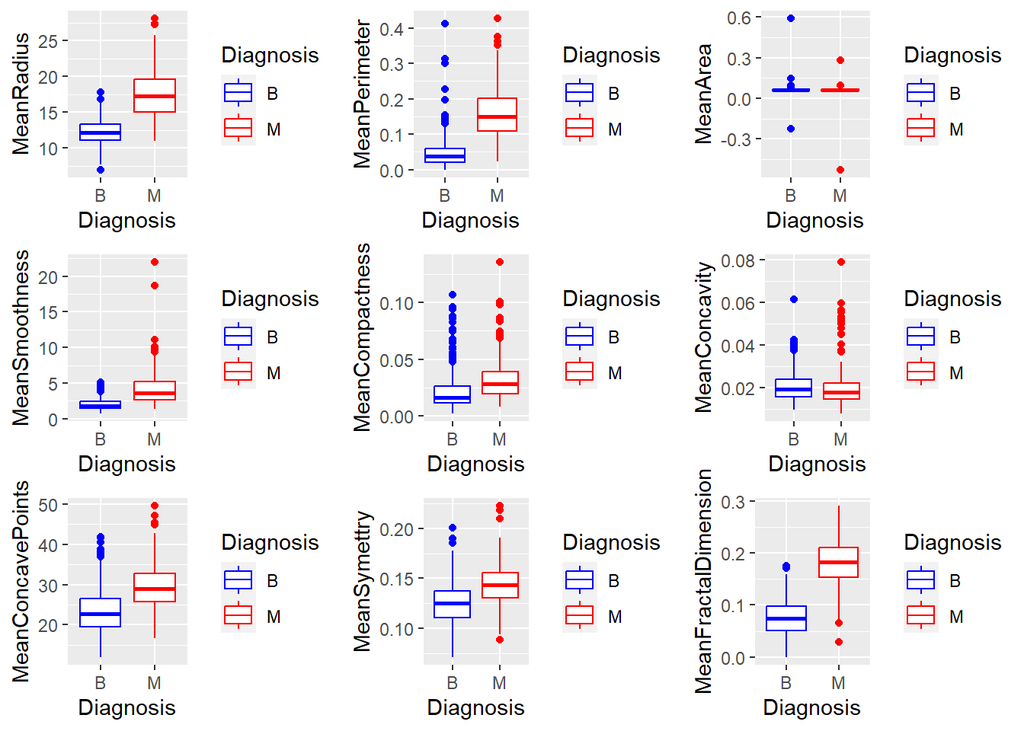

```r
b1 = ggplot(dataClean, aes(x= Diagnosis, y = MeanRadius, color=Diagnosis)) +
  geom_boxplot() + scale_color_manual(values=c('#0000FF','#FF0000'))

b2 = ggplot(dataClean, aes(x= Diagnosis, y = MeanPerimeter, color=Diagnosis)) +
  geom_boxplot() + scale_color_manual(values=c('#0000FF','#FF0000'))

b3 = ggplot(dataClean, aes(x= Diagnosis, y = MeanArea, color=Diagnosis)) +
  geom_boxplot() + scale_color_manual(values=c('#0000FF','#FF0000'))

b4 = ggplot(dataClean, aes(x= Diagnosis, y = MeanSmoothness, color=Diagnosis)) +
  geom_boxplot() + scale_color_manual(values=c('#0000FF','#FF0000'))

b5 = ggplot(dataClean, aes(x= Diagnosis, y = MeanCompactness, color=Diagnosis)) +
  geom_boxplot() + scale_color_manual(values=c('#0000FF','#FF0000'))

b6 = ggplot(dataClean, aes(x= Diagnosis, y = MeanConcavity, color=Diagnosis)) +
  geom_boxplot() + scale_color_manual(values=c('#0000FF','#FF0000'))

b7 = ggplot(dataClean, aes(x= Diagnosis, y = MeanConcavePoints, color=Diagnosis)) +
  geom_boxplot() + scale_color_manual(values=c('#0000FF','#FF0000'))

b8 = ggplot(dataClean, aes(x= Diagnosis, y = MeanSymettry, color=Diagnosis)) +
  geom_boxplot() + scale_color_manual(values=c('#0000FF','#FF0000'))

b9 = ggplot(dataClean, aes(x= Diagnosis, y = MeanFractalDimension, color=Diagnosis)) +
  geom_boxplot() + scale_color_manual(values=c('#0000FF','#FF0000'))

boxplots = ggarrange(b1, b2, b3, b4, b5, b6, b7, b8, b9)
boxplots
```

As we can observe there are many outliers for both benign and malign tumors. We are going to count them:

```r
# we will create a data frame that stores the number of outliers for every varaible
numberOfOutliers = data.frame(colnames(dataClean), rep(0, 29), rep(0,29))
colnames(numberOfOutliers) = c("Variable", "Normal", "Extreme")

# this vector will store the position of all the outliers
outlierIndex = c()


# counting regular outliers
for(i in 3:29){
  mean = mean(dataClean[,i])
  q25 = quantile(dataClean[,i], 0.25)
  names(q25) = NULL
  q75 = quantile(dataClean[,i], 0.75)
  names(q75) = NULL
  IQR = q75-q25
  numberOfOutliers$Normal[i] =  length(which(dataClean[,i] <  (q25-IQR*1.5)| dataClean[,i] > (q75+IQR*1.5)))
  for(j in 1:568){
    if(!(is.na(dataClean[j,i]))){
      if ((dataClean[j,i] <  (q25-IQR*1.5)| dataClean[j,i] > (q75+IQR*1.5))){
        if(!(j %in% outlierIndex)){
          outlierIndex = c(outlierIndex, j)
        }
      }
    }
  }
}

numberOfOutliers[,1:2]
```

```
##                   Variable Normal
## 1                       ID      0
## 2                Diagnosis      0
## 3               MeanRadius     14
## 4                 RadiusSD      7
## 5            RadiusLargest     15
## 6            MeanPerimeter     18
## 7              PerimeterSD     10
## 8         PerimeterLargest     15
## 9                 MeanArea     20
## 10                  AreaSD     37
## 11             AreaLargest     20
## 12          MeanSmoothness     37
## 13            SmoothnessSD     64
## 14       SmoothnessLargest     39
## 15         MeanCompactness     28
## 16           CompactnessSD     23
## 17      CompactnessLargest     19
## 18           MeanConcavity     27
## 19             ConcavitySD     29
## 20        ConcavityLargest     17
## 21       MeanConcavePoints      5
## 22         ConcavepointsSD     16
## 23    ConcavepointsLargest     32
## 24            MeanSymettry      7
## 25              SymmetrySD     16
## 26         SymmetryLargest     12
## 27    MeanFractalDimension      0
## 28      FractalDimensionSD     22
## 29 FractalDimensionLargest     24
```

In this data frame we can check the number of outliers for every variable. We will count them because there are a lot:

```r
# we will do this by using the length of the vector that stores
# the position of the outliers
# when the vector was created it was ensured that non indexes are repeated
length(outlierIndex)
```

```
## [1] 181
```

As we previously supposed the number is too big: 181. Removing 181/568 rows would suppose removing 31.87% of the data. This is too much so we will only remove the extreme outliers:

```r
# this vector will store the position of all the extreme outliers for all
# the variables
outlierExtremeIndex = c()
for (i in 3:29){
  mean = mean(dataClean[,i])
  q25 = quantile(dataClean[,i], 0.25)
  names(q25) = NULL
  q75 = quantile(dataClean[,i], 0.75)
  names(q75) = NULL
  IQR = q75-q25
  numberOfOutliers$Extreme[i] =  length(which(dataClean[,i] <  (q25-IQR*3)| dataClean[,i] > (q75+IQR*3)))

  for(j in 1:568){
    if(!(is.na(dataClean[j,i]))){
      if ((dataClean[j,i] <  (q25-IQR*3)| dataClean[j,i] > (q75+IQR*3))){
        if(!(j %in% outlierExtremeIndex)){
          outlierExtremeIndex = c(outlierExtremeIndex, j)

        }
      }
    }
  }
}
numberOfOutliers
```

```
##                   Variable Normal Extreme
## 1                       ID      0       0
## 2                Diagnosis      0       0
## 3               MeanRadius     14       1
## 4                 RadiusSD      7       1
## 5            RadiusLargest     15       0
## 6            MeanPerimeter     18       0
## 7              PerimeterSD     10       0
## 8         PerimeterLargest     15       1
## 9                 MeanArea     20       9
## 10                  AreaSD     37       9
## 11             AreaLargest     20       4
## 12          MeanSmoothness     37      12
## 13            SmoothnessSD     64      21
## 14       SmoothnessLargest     39      17
## 15         MeanCompactness     28       6
## 16           CompactnessSD     23       6
## 17      CompactnessLargest     19       3
## 18           MeanConcavity     27       9
## 19             ConcavitySD     29      12
## 20        ConcavityLargest     17       1
## 21       MeanConcavePoints      5       0
## 22         ConcavepointsSD     16       1
## 23    ConcavepointsLargest     32       7
## 24            MeanSymettry      7       0
## 25              SymmetrySD     16       3
## 26         SymmetryLargest     12       1
## 27    MeanFractalDimension      0       0
## 28      FractalDimensionSD     22       4
## 29 FractalDimensionLargest     24       2
```

As expected, there are less extreme outliers than regular ones. Lets count them:

```r
# we will do this by using the length of the vector that stores
# the position of the extreme outliers
# when the vector was created it was ensured that non indexes are repeated
length(outlierExtremeIndex)
```

```
## [1] 71
```

71/568 means removing 12.5% of the data. This is a much more reasonable amount. However, before removing them we will for curiosity check if these outliers maintain the same proportion bening/malign as the data set as a whole.

```r
length(which(data$Diagnosis[outlierExtremeIndex] == "M"))/length(outlierExtremeIndex)
```

```
## [1] 0.6478873
```

```r
length(which(data$Diagnosis== "M"))/length(data$Diagnosis)
```

```
## [1] 0.3714789
```

As we can observe inside the extreme outliers 64.79% of the data correspond to malign tumors. On the other hand in the data set in general, only 37.15% of the data correspond to malign tumors. This means, that if the tumor has extreme outlier values is much more likely that it is malign. However, we will still remove extreme outlier values as we are interested on seeing if there is any pattern in the data that inside regular values of the varaible determines either if a tumor is malign or benign.

```r
dataClean = dataClean[-outlierExtremeIndex,]
```

## **2.3 Correlation between variables**

We are interested in correlation between variables to see if there is any relationship between them. For the rest, of the assignment we will change the name of the variables to some abreviations as they are to big to show on plots:

```r
namesAux = c("ID", "D", "MR", "Rsd", "RL",
          "MP", "Psd", "PL",
          "MA", "Asd", "AL",
          "MS", "Ssd", "SL",
          "MCa", "Casd", "CaL",
          "MC", "Csd", "CL",
          "MCP", "CPsd", "CPL",
          "MSy", "Sysd", "SyL",
          "MF", "Fsd", "FL" )
colnames(dataClean) = namesAux

names = c("ID", "Diagnosis", "MeanRadius", "RadiusSD", "RadiusLargest",
          "MeanPerimeter", "PerimeterSD", "PerimeterLargest",
          "MeanArea", "AreaSD", "AreaLargest",
          "MeanSmoothness", "SmoothnessSD", "SmoothnessLargest",
          "MeanCompactness", "CompactnessSD", "CompactnessLargest",
          "MeanConcavity", "ConcavitySD", "ConcavityLargest",
          "MeanConcavePoints", "ConcavepointsSD", "ConcavepointsLargest",
          "MeanSymettry", "SymmetrySD", "SymmetryLargest",
          "MeanFractalDimension", "FractalDimensionSD", "FractalDimensionLargest" )
colnames(dataClean) = namesAux
# table with equivalences
equivalences = data.frame(namesAux, names)
colnames(equivalences) = c("Abreviation", "Real")
equivalences
```

```
##    Abreviation                    Real
## 1           ID                      ID
## 2            D               Diagnosis
## 3           MR              MeanRadius
## 4          Rsd                RadiusSD
## 5           RL           RadiusLargest
## 6           MP           MeanPerimeter
## 7          Psd             PerimeterSD
## 8           PL        PerimeterLargest
## 9           MA                MeanArea
## 10         Asd                  AreaSD
## 11          AL             AreaLargest
## 12          MS          MeanSmoothness
## 13         Ssd            SmoothnessSD
## 14          SL       SmoothnessLargest
## 15         MCa         MeanCompactness
## 16        Casd           CompactnessSD
## 17         CaL      CompactnessLargest
## 18          MC           MeanConcavity
## 19         Csd             ConcavitySD
## 20          CL        ConcavityLargest
## 21         MCP       MeanConcavePoints
## 22        CPsd         ConcavepointsSD
## 23         CPL    ConcavepointsLargest
## 24         MSy            MeanSymettry
## 25        Sysd              SymmetrySD
## 26         SyL         SymmetryLargest
## 27          MF    MeanFractalDimension
## 28         Fsd      FractalDimensionSD
## 29          FL FractalDimensionLargest
```

No we will create a plot for th correlation matrix:

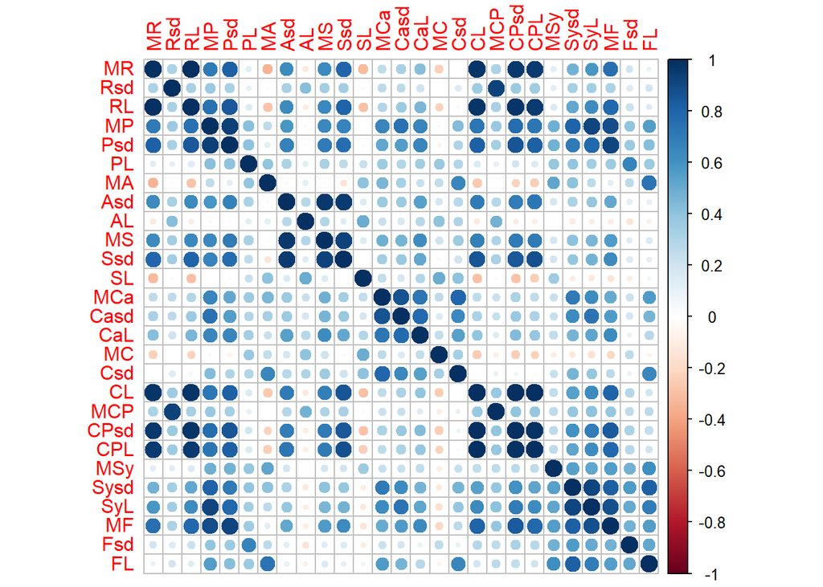

```r
corrMatrix = round(cor(dataClean[3:29]),2)

corrplot(corrMatrix, method="circle")
```

The darkest blue values correspond to strong positive correlations. It can be assumed “obvious” that in most of the analyzed cells characteristics there is correlation between the mean, largest value and sd. The plot shows that even though it is not super strong, the assumption holds in most cases. There are other interesting correlations that we should take a look at:

- Mean Perimeter (MP) and Mean Fractal Dimension (MF). (also with Symmetry Largest (SL))
- Mean Radius (MR) and the Largest Value of Concave Points (CPL)
- Mean Radius (MR) and Concave Points Standard Deviation (CPsd)
- Area Standard Deviation (Asd) and Smoothness Standard Deviation (Ssd)

We will proceed to analyze this correlations by visualizing the data.

## **2.4 Data visualization**

Before looking into the correlations lets comment the boxplots obtained when we removing the outliers:

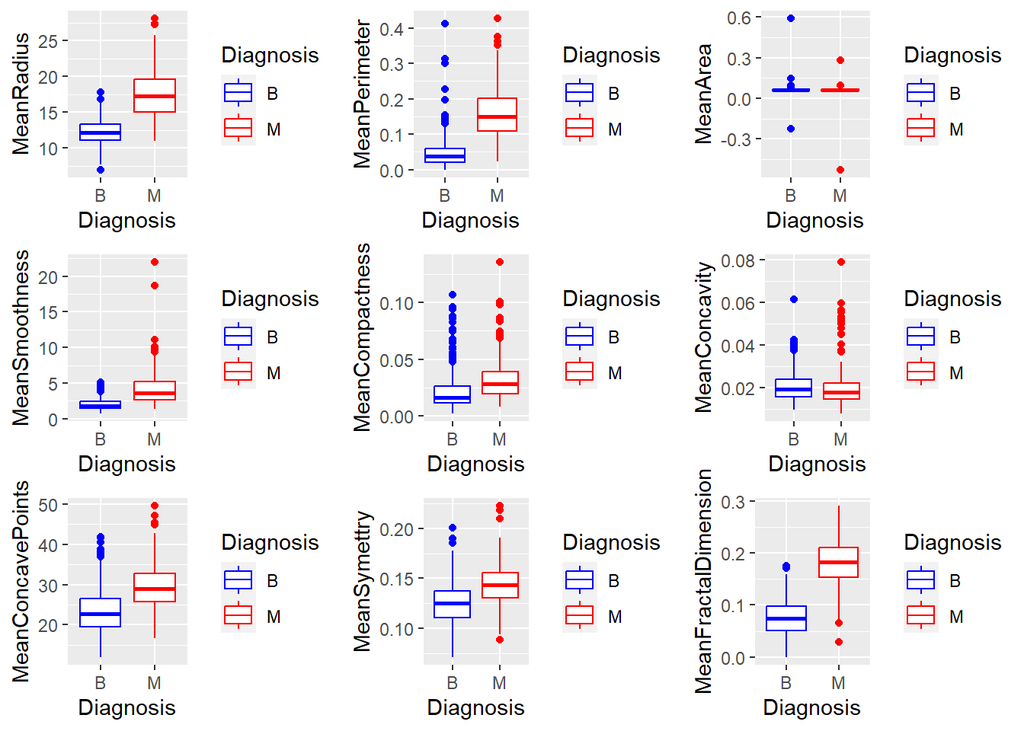

```r
boxplots
```

** Remember this plot was done before removing the extreme outliers.

Observing the plots, we can observe that for all the mean values (except for Mean Concavity and Mean Area) of the cell parameters analyzed those tumors who are malign (represented in red) have higher means. This, might be an indicator to identify a malign tumor. This also agrees with the data base authors claim: “largest values correspond to worst values”. This first look into the data would confirm this.

Lets proceed having a look at the correlations we found. In first case lets check the relationship between Mean Perimeter and Mean Fractal Dimension:

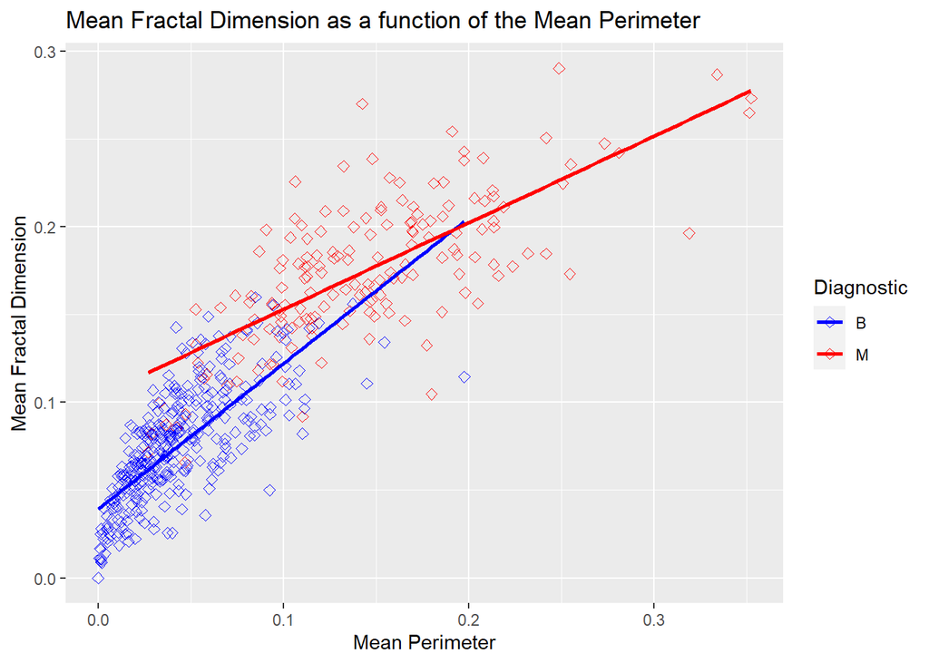

```r
ggplot(dataClean, aes(x=MP, y=MF, color = D)) +
  geom_point(size=2, shape=23) + geom_smooth(method=lm, se=FALSE, formula = y~x) + scale_color_manual(values=c('#0000FF','#FF0000')) +
  xlab("Mean Perimeter") + ylab("Mean Fractal Dimension") + labs(color = "Diagnostic") +
  ggtitle("Mean Fractal Dimension as a function of the Mean Perimeter")
```

There is a clear separation between data corresponding to malign and benign tumors. Malign tumors have a higher values both for Mean Fractal Dimension and Mean Perimeter. Also, when comparing Mean Fractal Dimension as a linear function of the Mean Perimeter we can observe that Benign data has a higher slope than malign.

We also saw in the correlation plot that Mean Perimeter also has correlation with the Symmetry largest value so lets include this variable transforming the previous graph into a bubble graph:

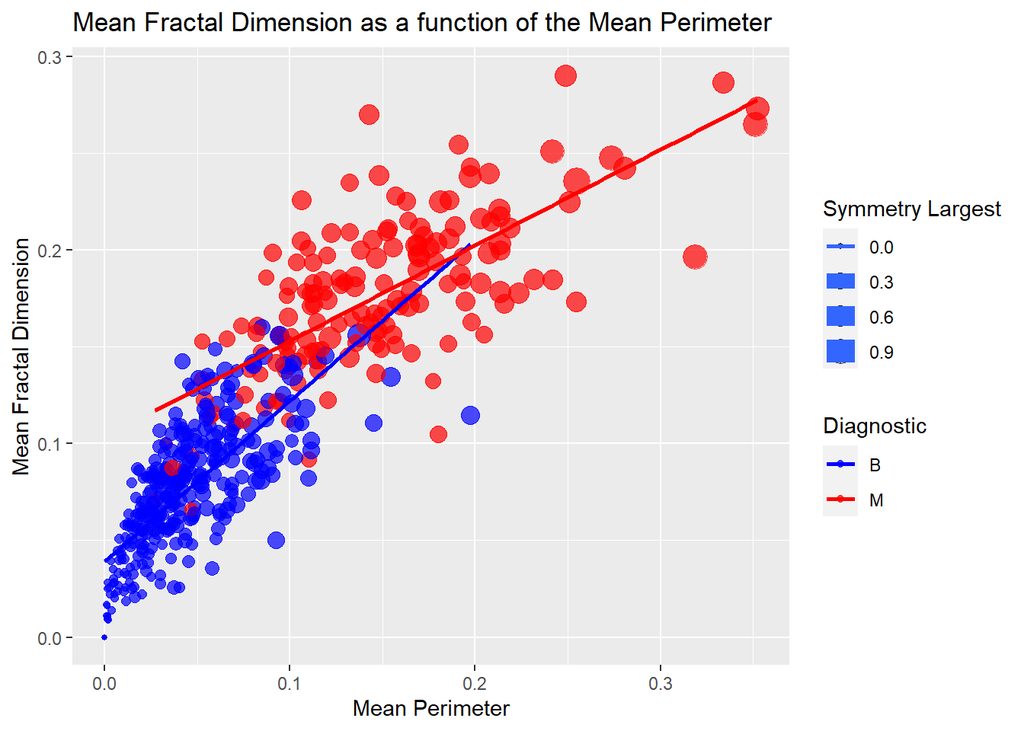

```r
ggplot(dataClean, aes(x=MP, y=MF, size = SyL, color = D)) +
  geom_point(alpha=0.7) + geom_smooth(method=lm, se=FALSE, formula = y~x) +
  xlab("Mean Perimeter") + ylab("Mean Fractal Dimension") + labs(color = "Diagnostic", size = "Symmetry Largest") +
  ggtitle("Mean Fractal Dimension as a function of the Mean Perimeter") + scale_color_manual(values=c('#0000FF','#FF0000'))
```

The size of the bubbles corresponds to the Symmetry largest values. As we can see malign points (red bubbles) have a bigger size than benign points(blue bubbles). This corresponds with what was observed in the box-plots. Also, as we know from the correlation plot, the Symmetry Largest Value (size of the bubbles) increases with the Mean Perimeter.

The second correlation we want to visualize is Mean Radius and the Largest Value of Concave Points:

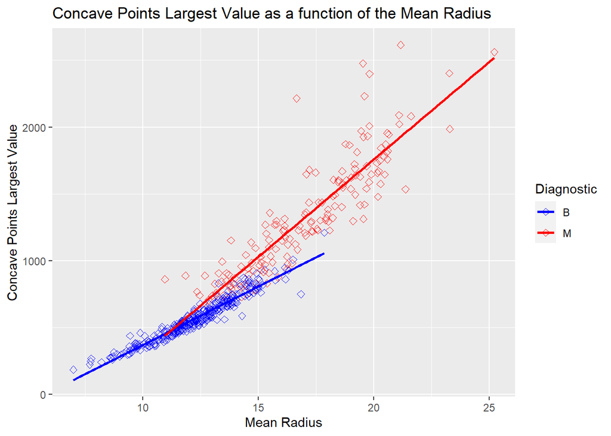

```r
ggplot(dataClean, aes(x=MR, y=CPL, color = D)) +
  geom_point(size=2, shape=23) + geom_smooth(method=lm, se=FALSE, formula = y~x) + scale_color_manual(values=c('#0000FF','#FF0000')) +
  xlab("Mean Radius") + ylab("Concave Points Largest Value") + labs(color = "Diagnostic") +
  ggtitle("Concave Points Largest Value as a function of the Mean Radius")
```

Again there is a clear differentiation between points corresponding to malign and benign tumors.However this time, the best fit linear line of Concave Points Largest Value as a function of the Mean Radius corresponding to malign tumors has a higher slope than the one for benign. In this graph we can see that the data are very close to the best fit lines which indicates that the linear assumption for the best fit line might be a good one.

The third strong correlation to analyze is between Mean Radius and Concave Points Standard Deviation:

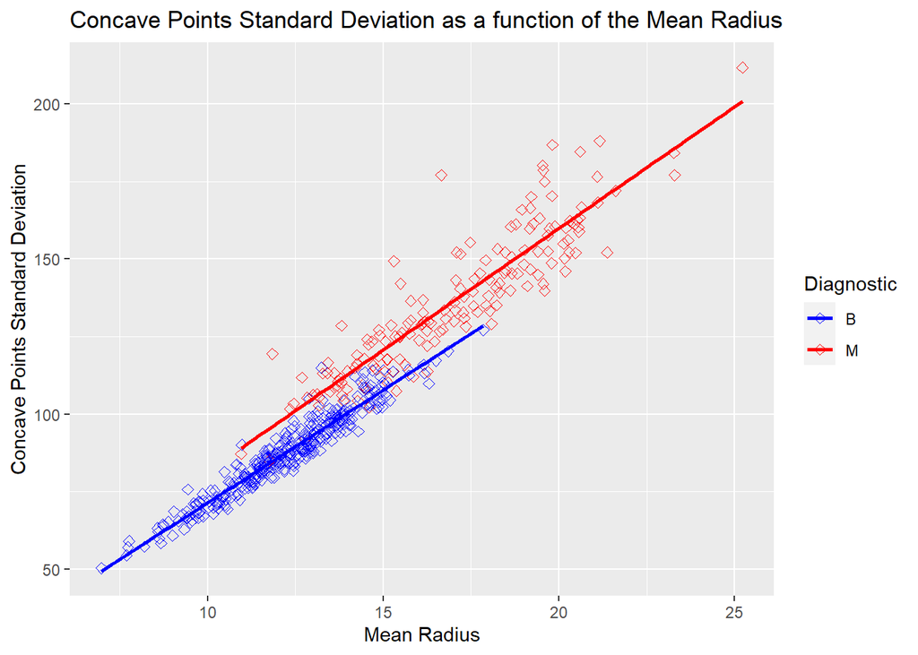

```r
ggplot(dataClean, aes(x=MR, y=CPsd, color = D)) +
  geom_point(size=2, shape=23) + geom_smooth(method=lm, se=FALSE, ) + scale_color_manual(values=c('#0000FF','#FF0000')) +
  xlab("Mean Radius") + ylab("Concave Points Standard Deviation") + labs(color = "Diagnostic") +
  ggtitle("Concave Points Standard Deviation as a function of the Mean Radius")
```

As in the previous graphs, there is a clear differentiation between malign an benign tumors. This time, the slopes of the linear best fit functions of Concave Points sd as a function of the Mean Radius are almost equal (visually). However again, malign data are above benign data.

Lastly, we want to visualize the correlation between Area Sd and Smoothness Sd:

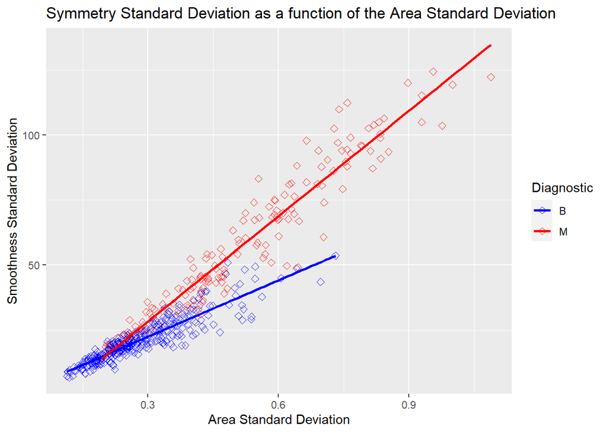

```r
ggplot(dataClean, aes(x=Asd, y=Ssd, color = D)) +
  geom_point(size=2, shape=23) + geom_smooth(method=lm, se=FALSE) + scale_color_manual(values=c('#0000FF','#FF0000')) +
  xlab("Area Standard Deviation") + ylab("Smoothness Standard Deviation") + labs(color = "Diagnostic") +
  ggtitle("Symmetry Standard Deviation as a function of the Area Standard Deviation")
```

The linear best fit line of Smoothess Sd as a function of Area Sd has a bigger slope for malign data. As in all the previous graphs we can see again a clear differentiation between malign and benign data.

The last plot that we are going to check is a heat map between Mean Radius and Mean Smoothness. This is because these are the two variables with a greater difference between the means of benign and malign data as we can observe in the box-plots showed previously. We will only make on heat map without differientiating between malign and benign data:

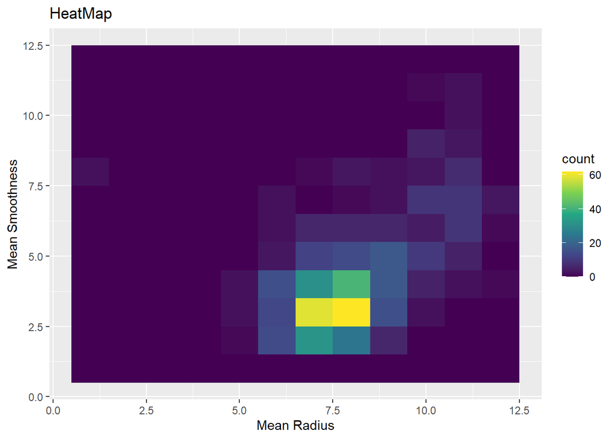

```r
# creating a secondary data se for the heat map
x1 = c(1:12)
y1  = c(1:12)
heatmap_matrix = expand.grid(X = x1, Y = y1)
heatmap_matrix$count = 0

for(i in 1:length(dataClean$ID)){
  aux1 = 0
  aux2 = 0.7
  aux3 = 0
  aux4 = 2.1
  index = 1
  for(j in 1:12){
    if(dataClean$MS[i] >= aux1 && dataClean$MS[i] < aux2){
      for(h in 1:12){
        if(dataClean$MR[i] >= aux3 && dataClean$MR[i] < aux4){
          heatmap_matrix$count[index+h] = heatmap_matrix$count[index+h] + 1
        }
        aux3 = aux3 + 2.1
        aux4 = aux4 + 2.1
      }

    }
    index = index + 12
    aux1 = aux1 + 0.7
    aux2 = aux2 + 0.7
  }

}

# heat map
ggplot(heatmap_matrix, aes(X, Y, fill= count)) +
  geom_tile() +scale_fill_viridis_c() + ggtitle("HeatMap") +
  xlab("Mean Radius") + ylab("Mean Smoothness")
```

## **2.5 Changing variables data type**

Lastly for Data Preprocessing, we must make all the variables data type numeric. Lets check the actual type:

```r
str(dataClean)
```

```
## 'data.frame':    497 obs. of  29 variables:
##  $ ID  : int  842517 84300903 84358402 843786 844359 84458202 844981 845636 84610002 846381 ...
##  $ D   : chr  "M" "M" "M" "M" ...
##  $ MR  : num  20.6 19.7 20.3 12.4 18.2 ...
##  $ Rsd : num  17.8 21.2 14.3 15.7 20 ...
##  $ RL  : num  132.9 130 135.1 82.6 119.6 ...
##  $ MP  : num  0.0869 0.1974 0.198 0.1578 0.1127 ...
##  $ Psd : num  0.0702 0.1279 0.1043 0.0809 0.074 ...
##  $ PL  : num  0.181 0.207 0.181 0.209 0.179 ...
##  $ MA  : num  0.0567 0.06 0.0588 0.0761 0.0574 ...
##  $ Asd : num  0.543 0.746 0.757 0.335 0.447 ...
##  $ AL  : num  0.734 0.787 0.781 0.89 0.773 ...
##  $ MS  : num  3.4 4.58 5.44 2.22 3.18 ...
##  $ Ssd : num  74.1 94 94.4 27.2 53.9 ...
##  $ SL  : num  0.00522 0.00615 0.01149 0.00751 0.00431 ...
##  $ MCa : num  0.0131 0.0401 0.0246 0.0335 0.0138 ...
##  $ Casd: num  0.0186 0.0383 0.0569 0.0367 0.0225 ...
##  $ CaL : num  0.0134 0.0206 0.0188 0.0114 0.0104 ...
##  $ MC  : num  0.0139 0.0225 0.0176 0.0216 0.0137 ...
##  $ Csd : num  0.00353 0.00457 0.00511 0.00508 0.00218 ...
##  $ CL  : num  25 23.6 22.5 15.5 22.9 ...
##  $ MCP : num  23.4 25.5 16.7 23.8 27.7 ...
##  $ CPsd: num  159 152 152 103 153 ...
##  $ CPL : num  1956 1709 1575 742 1606 ...
##  $ MSy : num  0.124 0.144 0.137 0.179 0.144 ...
##  $ Sysd: num  0.187 0.424 0.205 0.525 0.258 ...
##  $ SyL : num  0.242 0.45 0.4 0.535 0.378 ...
##  $ MF  : num  0.186 0.243 0.163 0.174 0.193 ...
##  $ Fsd : num  0.275 0.361 0.236 0.399 0.306 ...
##  $ FL  : num  0.089 0.0876 0.0768 0.1244 0.0837 ...
```

Right now, only ID and Diagnosis are not numeric. ID will not be a useful variable throughout the assignment because it is only an identifier of the patient, it has no relation at all with the tumor. Therefore we will remove it from the clean data set.

```r
dataClean = dataClean[,-1]
```

Finally, we will factor tha Diagnosis column. Malign will now be equal to 2 and Benign equal to 1:

```r
dataClean$D = factor(dataClean$D, levels = c("B", "M"), labels = c("Benign","Malign"))
str(dataClean)
```

```
## 'data.frame':    497 obs. of  28 variables:
##  $ D   : Factor w/ 2 levels "Benign","Malign": 2 2 2 2 2 2 2 2 2 2 ...
##  $ MR  : num  20.6 19.7 20.3 12.4 18.2 ...
##  $ Rsd : num  17.8 21.2 14.3 15.7 20 ...
##  $ RL  : num  132.9 130 135.1 82.6 119.6 ...
##  $ MP  : num  0.0869 0.1974 0.198 0.1578 0.1127 ...
##  $ Psd : num  0.0702 0.1279 0.1043 0.0809 0.074 ...
##  $ PL  : num  0.181 0.207 0.181 0.209 0.179 ...
##  $ MA  : num  0.0567 0.06 0.0588 0.0761 0.0574 ...
##  $ Asd : num  0.543 0.746 0.757 0.335 0.447 ...
##  $ AL  : num  0.734 0.787 0.781 0.89 0.773 ...
##  $ MS  : num  3.4 4.58 5.44 2.22 3.18 ...
##  $ Ssd : num  74.1 94 94.4 27.2 53.9 ...
##  $ SL  : num  0.00522 0.00615 0.01149 0.00751 0.00431 ...
##  $ MCa : num  0.0131 0.0401 0.0246 0.0335 0.0138 ...
##  $ Casd: num  0.0186 0.0383 0.0569 0.0367 0.0225 ...
##  $ CaL : num  0.0134 0.0206 0.0188 0.0114 0.0104 ...
##  $ MC  : num  0.0139 0.0225 0.0176 0.0216 0.0137 ...
##  $ Csd : num  0.00353 0.00457 0.00511 0.00508 0.00218 ...
##  $ CL  : num  25 23.6 22.5 15.5 22.9 ...
##  $ MCP : num  23.4 25.5 16.7 23.8 27.7 ...
##  $ CPsd: num  159 152 152 103 153 ...
##  $ CPL : num  1956 1709 1575 742 1606 ...
##  $ MSy : num  0.124 0.144 0.137 0.179 0.144 ...
##  $ Sysd: num  0.187 0.424 0.205 0.525 0.258 ...
##  $ SyL : num  0.242 0.45 0.4 0.535 0.378 ...
##  $ MF  : num  0.186 0.243 0.163 0.174 0.193 ...
##  $ Fsd : num  0.275 0.361 0.236 0.399 0.306 ...
##  $ FL  : num  0.089 0.0876 0.0768 0.1244 0.0837 ...
```

Now they are all numeric so we are set to start with the modelling.

# **3. Multiple Regression**

Before starting with anything we must divide our data set in a train ar test set. We will have 80% of our data in the training test:

```r
split = createDataPartition(dataClean$D, p = 0.8, list = FALSE)

dataTrain = dataClean[split,]
dataTest = dataClean[-split,]
```

## **3.1 LDA**

We will start by creating a LDA classification model. First we need to know the dsitribution of Benign and Malign data along the training set:

```r
table(dataTrain$D)
```

```
##
## Benign Malign
##    266    132
```

Around 2/3 of the data correspond to benign tumors and 1/3 to malign ones. We will crate a model following this percentages:

```r
lda.model = lda(D ~ ., data = dataTrain, prior = c(2/3, 1/3))

lda.model
```

```
## Call:
## lda(D ~ ., data = dataTrain, prior = c(2/3, 1/3))
##
## Prior probabilities of groups:
##    Benign    Malign
## 0.6666667 0.3333333
##
## Group means:
##              MR      Rsd        RL         MP        Psd        PL         MA
## Benign 12.26005 17.98609  78.76008 0.04118391 0.02478057 0.1720816 0.06208237
## Malign 16.86000 21.68826 111.08932 0.14544106 0.08060841 0.1894439 0.06228182
##              Asd       AL       MS      Ssd          SL        MCa       Casd
## Benign 0.2749763 1.169077 1.932770 20.67630 0.006967662 0.01931815 0.02182233
## Malign 0.5148652 1.171127 3.622409 57.26712 0.006440720 0.02954640 0.03758318
##                CaL         MC         Csd       CL      MCP      CPsd       CPL
## Benign 0.009221564 0.02008225 0.003198012 13.49556 23.60184  87.73756  566.8837
## Malign 0.013838879 0.01846445 0.003828758 20.31886 29.68159 135.56409 1305.1552
##              MSy      Sysd       SyL        MF       Fsd         FL
## Benign 0.1252661 0.1788955 0.1568435 0.0731123 0.2692816 0.07820346
## Malign 0.1451721 0.3685558 0.4375492 0.1746948 0.3200242 0.09182288
##
## Coefficients of linear discriminants:
##                LD1
## MR     0.914259701
## Rsd   -0.042691383
## RL    -0.162350402
## MP    12.539739907
## Psd    3.974973967
## PL     0.288373514
## MA   -55.731446761
## Asd    0.799510893
## AL    -0.321907200
## MS    -0.043593273
## Ssd    0.009082929
## SL    68.639873205
## MCa    4.465321640
## Casd -13.484888680
## CaL    0.709206825
## MC    28.662261903
## Csd  -63.661201095
## CL     0.325360122
## MCP    0.087688249
## CPsd   0.029431218
## CPL   -0.002340771
## MSy    0.811652548
## Sysd  -4.351138469
## SyL    0.636207365
## MF     8.582609757
## Fsd    3.279552856
## FL    41.273550910
```

First relevant thing we can observe is that in almost every variable, the difference between the mean of benign and malign tumors are significantly different. This is something we already noticed in the data visualization and is an indicator that we might be able to classify data with a high accuracy. We will now build another lda model but without any previous percentages:

```r
lda.model = lda(D ~ ., data = dataTrain)
lda.model
```

```
## Call:
## lda(D ~ ., data = dataTrain)
##
## Prior probabilities of groups:
##    Benign    Malign
## 0.6683417 0.3316583
##
## Group means:
##              MR      Rsd        RL         MP        Psd        PL         MA
## Benign 12.26005 17.98609  78.76008 0.04118391 0.02478057 0.1720816 0.06208237
## Malign 16.86000 21.68826 111.08932 0.14544106 0.08060841 0.1894439 0.06228182
##              Asd       AL       MS      Ssd          SL        MCa       Casd
## Benign 0.2749763 1.169077 1.932770 20.67630 0.006967662 0.01931815 0.02182233
## Malign 0.5148652 1.171127 3.622409 57.26712 0.006440720 0.02954640 0.03758318
##                CaL         MC         Csd       CL      MCP      CPsd       CPL
## Benign 0.009221564 0.02008225 0.003198012 13.49556 23.60184  87.73756  566.8837
## Malign 0.013838879 0.01846445 0.003828758 20.31886 29.68159 135.56409 1305.1552
##              MSy      Sysd       SyL        MF       Fsd         FL
## Benign 0.1252661 0.1788955 0.1568435 0.0731123 0.2692816 0.07820346
## Malign 0.1451721 0.3685558 0.4375492 0.1746948 0.3200242 0.09182288
##
## Coefficients of linear discriminants:
##                LD1
## MR     0.914259701
## Rsd   -0.042691383
## RL    -0.162350402
## MP    12.539739907
## Psd    3.974973967
## PL     0.288373514
## MA   -55.731446761
## Asd    0.799510893
## AL    -0.321907200
## MS    -0.043593273
## Ssd    0.009082929
## SL    68.639873205
## MCa    4.465321640
## Casd -13.484888680
## CaL    0.709206825
## MC    28.662261903
## Csd  -63.661201095
## CL     0.325360122
## MCP    0.087688249
## CPsd   0.029431218
## CPL   -0.002340771
## MSy    0.811652548
## Sysd  -4.351138469
## SyL    0.636207365
## MF     8.582609757
## Fsd    3.279552856
## FL    41.273550910
```

The distribution of benign and malign tumor is pretty much the same, and we can see the same tendency with the means. We will stick with this model. We will create a vector that stores the probability of each data from the test set of being benign or malign:

```r
probability = predict(lda.model, newdata = dataTest)$posterior
head(probability)
```

```
##          Benign       Malign
## 1  1.630858e-04 9.998369e-01
## 8  5.714987e-03 9.942850e-01
## 17 6.811660e-06 9.999932e-01
## 21 9.999989e-01 1.134483e-06
## 23 7.733494e-07 9.999992e-01
## 45 1.075003e-05 9.999892e-01
```

The first observations have a greater probability of being malign. We will now assign predictions based on if they higher probability of being malign or benign:

```r
prediction = max.col(probability)
```

Another way of doing this is directly using the predict function:

```r
prediction = predict(lda.model, newdata = dataTest)$class
```

Lets check how the results came:

```r
confusionMatrix(prediction, dataTest$D)$table
```

```
##           Reference
## Prediction Benign Malign
##     Benign     66      3
##     Malign      0     30
```

```r
confusionMatrix(prediction, dataTest$D)$overall[1]
```

```
## Accuracy
## 0.969697
```

## **3.2 QDA**

We will build a QDA model to see how accurate it is. Again we will start by fixing the proababilities:

```r
qda.model = qda(D ~ ., data = dataTrain, prior = c(2/3, 1/3))
qda.model
```

```
## Call:
## qda(D ~ ., data = dataTrain, prior = c(2/3, 1/3))
##
## Prior probabilities of groups:
##    Benign    Malign
## 0.6666667 0.3333333
##
## Group means:
##              MR      Rsd        RL         MP        Psd        PL         MA
## Benign 12.26005 17.98609  78.76008 0.04118391 0.02478057 0.1720816 0.06208237
## Malign 16.86000 21.68826 111.08932 0.14544106 0.08060841 0.1894439 0.06228182
##              Asd       AL       MS      Ssd          SL        MCa       Casd
## Benign 0.2749763 1.169077 1.932770 20.67630 0.006967662 0.01931815 0.02182233
## Malign 0.5148652 1.171127 3.622409 57.26712 0.006440720 0.02954640 0.03758318
##                CaL         MC         Csd       CL      MCP      CPsd       CPL
## Benign 0.009221564 0.02008225 0.003198012 13.49556 23.60184  87.73756  566.8837
## Malign 0.013838879 0.01846445 0.003828758 20.31886 29.68159 135.56409 1305.1552
##              MSy      Sysd       SyL        MF       Fsd         FL
## Benign 0.1252661 0.1788955 0.1568435 0.0731123 0.2692816 0.07820346
## Malign 0.1451721 0.3685558 0.4375492 0.1746948 0.3200242 0.09182288
```

Again a clear distinction between the means of benign and malign. Lets check without fixing probabilities:

```r
qda.model = qda(D ~ ., data = dataTrain)
qda.model
```

```
## Call:
## qda(D ~ ., data = dataTrain)
##
## Prior probabilities of groups:
##    Benign    Malign
## 0.6683417 0.3316583
##
## Group means:
##              MR      Rsd        RL         MP        Psd        PL         MA
## Benign 12.26005 17.98609  78.76008 0.04118391 0.02478057 0.1720816 0.06208237
## Malign 16.86000 21.68826 111.08932 0.14544106 0.08060841 0.1894439 0.06228182
##              Asd       AL       MS      Ssd          SL        MCa       Casd
## Benign 0.2749763 1.169077 1.932770 20.67630 0.006967662 0.01931815 0.02182233
## Malign 0.5148652 1.171127 3.622409 57.26712 0.006440720 0.02954640 0.03758318
##                CaL         MC         Csd       CL      MCP      CPsd       CPL
## Benign 0.009221564 0.02008225 0.003198012 13.49556 23.60184  87.73756  566.8837
## Malign 0.013838879 0.01846445 0.003828758 20.31886 29.68159 135.56409 1305.1552
##              MSy      Sysd       SyL        MF       Fsd         FL
## Benign 0.1252661 0.1788955 0.1568435 0.0731123 0.2692816 0.07820346
## Malign 0.1451721 0.3685558 0.4375492 0.1746948 0.3200242 0.09182288
```

We get almost the same data distribution. We will stick with this. We predict directly:

```r
prediction = predict(qda.model, newdata = dataTest)$class
confusionMatrix(prediction, dataTest$D)$table
```

```
##           Reference
## Prediction Benign Malign
##     Benign     61      2
##     Malign      5     31
```

```r
confusionMatrix(prediction, dataTest$D)$overall[1]
```

```
##  Accuracy
## 0.9292929
```

## **3.3 Decision tree**

Lets continue by exploring decision trees. First of all we need to understand the parameters that modify them:

- Minsplit: Minimum number of observations needed for an split to be created.
- Maxdepth: Maximum depth of the nodes of the tree.
- Cp: Degree of complexity of the tree. The smaller the cp, more branches.

Lets create a first tree by using the following hyper-parameters:

```r
control_hyper = rpart.control(minsplit = 30, maxdepth = 10, cp=0.01)
model = D ~.
dtFit <- rpart(model, data=dataTrain, method = "class", control = control_hyper)
summary(dtFit)
```

```
## Call:
## rpart(formula = model, data = dataTrain, method = "class", control = control_hyper)
##   n= 398
##
##           CP nsplit rel error    xerror       xstd
## 1 0.79545455      0 1.0000000 1.0000000 0.07115613
## 2 0.04545455      1 0.2045455 0.2348485 0.04050405
## 3 0.02272727      2 0.1590909 0.2424242 0.04109605
## 4 0.01000000      3 0.1363636 0.2121212 0.03865133
##
## Variable importance
## CPsd  CPL   CL   RL   MF   MR  MCP  Rsd Sysd  SyL
##   18   16   16   14   14   14    2    2    1    1
##
## Node number 1: 398 observations,    complexity param=0.7954545
##   predicted class=Benign  expected loss=0.3316583  P(node) =1
##     class counts:   266   132
##    probabilities: 0.668 0.332
##   left son=2 (259 obs) right son=3 (139 obs)
##   Primary splits:
##       CPsd < 106.2   to the left,  improve=127.3727, (0 missing)
##       CPL  < 865.7   to the left,  improve=122.9268, (0 missing)
##       CL   < 16.79   to the left,  improve=122.7247, (0 missing)
##       MF   < 0.1417  to the left,  improve=121.2593, (0 missing)
##       Psd  < 0.05142 to the left,  improve=120.2142, (0 missing)
##   Surrogate splits:
##       CPL < 784.15  to the left,  agree=0.970, adj=0.914, (0 split)
##       CL  < 16.16   to the left,  agree=0.967, adj=0.906, (0 split)
##       RL  < 90.37   to the left,  agree=0.930, adj=0.799, (0 split)
##       MR  < 14.15   to the left,  agree=0.917, adj=0.763, (0 split)
##       MF  < 0.11825 to the left,  agree=0.902, adj=0.719, (0 split)
##
## Node number 2: 259 observations,    complexity param=0.02272727
##   predicted class=Benign  expected loss=0.03861004  P(node) =0.6507538
##     class counts:   249    10
##    probabilities: 0.961 0.039
##   left son=4 (244 obs) right son=5 (15 obs)
##   Primary splits:
##       MF   < 0.1347  to the left,  improve=10.036000, (0 missing)
##       SyL  < 0.3695  to the left,  improve= 8.403309, (0 missing)
```

[output cut: 32 more lines]

```
##
## Node number 5: 15 observations
##   predicted class=Malign  expected loss=0.4  P(node) =0.03768844
##     class counts:     6     9
##    probabilities: 0.400 0.600
##
## Node number 6: 20 observations
##   predicted class=Benign  expected loss=0.35  P(node) =0.05025126
##     class counts:    13     7
##    probabilities: 0.650 0.350
##
## Node number 7: 119 observations
##   predicted class=Malign  expected loss=0.03361345  P(node) =0.298995
##     class counts:     4   115
##    probabilities: 0.034 0.966
```

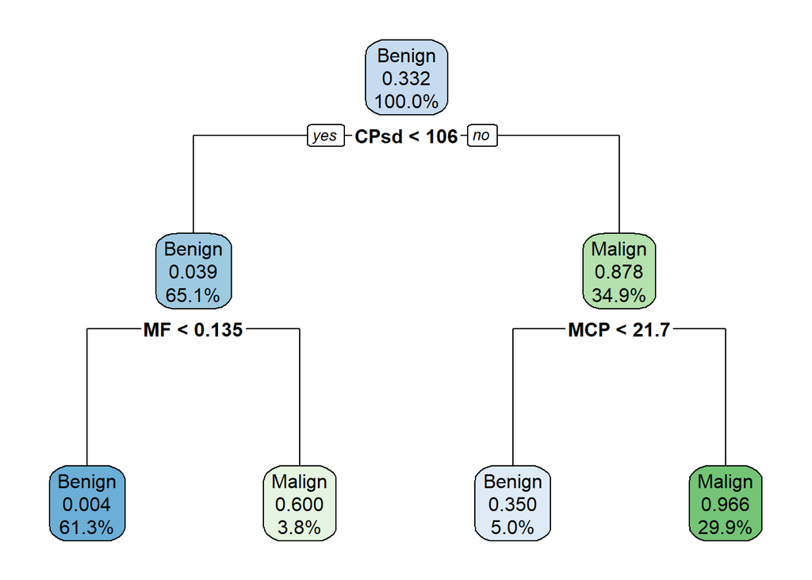

```r
rpart.plot(dtFit, digits=3)
```

We should also highlight that in every node, when the condition is checked, the side with the lower part of the condition corresponds to to the benign tumors. This agrees with the graphs we saw where always malign tumors had bigger values. It also agrees with the idea exposed in the introduction that largest values correspond to “worst case” values.

Lets modify decrease the cp (aument the complexity) and see what happens:

```r
control_hyper = rpart.control(minsplit = 40, maxdepth = 12, cp=0.001)
dtFit = rpart(model, data=dataTrain, method = "class", control = control_hyper)
summary(dtFit)
```

```
## Call:
## rpart(formula = model, data = dataTrain, method = "class", control = control_hyper)
##   n= 398
##
##           CP nsplit rel error    xerror       xstd
## 1 0.79545455      0 1.0000000 1.0000000 0.07115613
## 2 0.04545455      1 0.2045455 0.2803030 0.04388731
## 3 0.02272727      2 0.1590909 0.2272727 0.03989965
## 4 0.00100000      3 0.1363636 0.1818182 0.03597708
##
## Variable importance
## CPsd  CPL   CL   RL   MF   MR  MCP  Rsd Sysd  SyL
##   18   16   16   14   14   14    2    2    1    1
##
## Node number 1: 398 observations,    complexity param=0.7954545
##   predicted class=Benign  expected loss=0.3316583  P(node) =1
##     class counts:   266   132
##    probabilities: 0.668 0.332
##   left son=2 (259 obs) right son=3 (139 obs)
##   Primary splits:
##       CPsd < 106.2   to the left,  improve=127.3727, (0 missing)
##       CPL  < 865.7   to the left,  improve=122.9268, (0 missing)
##       CL   < 16.79   to the left,  improve=122.7247, (0 missing)
##       MF   < 0.1417  to the left,  improve=121.2593, (0 missing)
##       Psd  < 0.05142 to the left,  improve=120.2142, (0 missing)
##   Surrogate splits:
##       CPL < 784.15  to the left,  agree=0.970, adj=0.914, (0 split)
##       CL  < 16.16   to the left,  agree=0.967, adj=0.906, (0 split)
##       RL  < 90.37   to the left,  agree=0.930, adj=0.799, (0 split)
##       MR  < 14.15   to the left,  agree=0.917, adj=0.763, (0 split)
##       MF  < 0.11825 to the left,  agree=0.902, adj=0.719, (0 split)
##
## Node number 2: 259 observations,    complexity param=0.02272727
##   predicted class=Benign  expected loss=0.03861004  P(node) =0.6507538
##     class counts:   249    10
##    probabilities: 0.961 0.039
##   left son=4 (244 obs) right son=5 (15 obs)
##   Primary splits:
##       MF   < 0.1347  to the left,  improve=10.036000, (0 missing)
##       SyL  < 0.3695  to the left,  improve= 8.403309, (0 missing)
```

[output cut: 32 more lines]

```
##
## Node number 5: 15 observations
##   predicted class=Malign  expected loss=0.4  P(node) =0.03768844
##     class counts:     6     9
##    probabilities: 0.400 0.600
##
## Node number 6: 20 observations
##   predicted class=Benign  expected loss=0.35  P(node) =0.05025126
##     class counts:    13     7
##    probabilities: 0.650 0.350
##
## Node number 7: 119 observations
##   predicted class=Malign  expected loss=0.03361345  P(node) =0.298995
##     class counts:     4   115
##    probabilities: 0.034 0.966
```

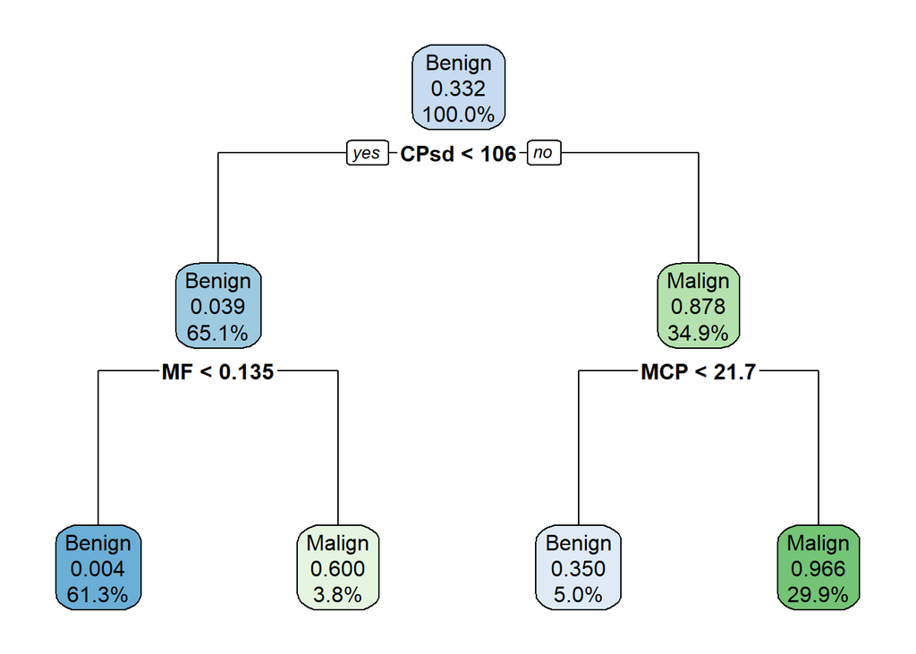

```r
rpart.plot(dtFit, digits = 3)
```

```r
dtPred = predict(dtFit, dataTest, type = "class")
dtProb = predict(dtFit, dataTest, type = "prob")
threshold = 0.2
dtPred = rep("Benign", nrow(dataTest))
dtPred[which(dtProb[,2] > threshold)] = "Malign"
CM = confusionMatrix(factor(dtPred), dataTest$D)$table
CM
```

```
##           Reference
## Prediction Benign Malign
##     Benign     55      1
##     Malign     11     32
```

```r
confusionMatrix(factor(dtPred), dataTest$D)$overall[1]
```

```
##  Accuracy
## 0.8787879
```

We will now create a grid with different combination of hyper-parameters:

```r
cp = seq(from = 0.001, to = 0.015, by = 0.005)
maxdepth = seq(from = 2, to =10, by = 2)
minsplit = seq(from = 10, to = 100, by = 5)
control_hyperparams = expand.grid(cp, maxdepth,minsplit)
control_hyperparams$acc = 0
```

We will create all the trees and store the accuracies:

```r
for(i in 1:length(control_hyperparams$Var1)){
  control_hyper = rpart.control(minsplit = control_hyperparams[i,3], maxdepth = control_hyperparams[i,2], cp = control_hyperparams[i,1])
  dtFit <- rpart(model, data=dataTrain, method = "class", control = control_hyper)
  dtPred <- predict(dtFit, dataTest, type = "class")
  dtProb <- predict(dtFit, dataTest, type = "prob")
  threshold = 0.2
  dtPred = rep("Benign", nrow(dataTest))
  dtPred[which(dtProb[,2] > threshold)] = "Malign"
  CM = confusionMatrix(factor(dtPred), dataTest$D)$table
  control_hyperparams$acc[i] = confusionMatrix(factor(dtPred), dataTest$D)$overall[1]
}
```

Now, we check the range of the accuracies:

```r
range(control_hyperparams$acc)
```

```
## [1] 0.8585859 0.9393939
```

With all the combination of hyper-parameters the range of accuracies is very high. This makes sense with the visualization done as we could see clear distinctions between malign and benign data. However, this does not suggest an specific tree to use. Lets see wht random forest says:

## **3.4 Random Forest**

We will start by creating a forest with 200 trees to classify the variable Diagnostic:

```r
rf.train = randomForest(D ~., data=dataTrain, ntree=200,mtry=10,cutoff=c(0.75,0.25),importance=TRUE, do.trace=T)
```

```
## ntree      OOB      1      2
##     1:   8.72% 11.58%  3.70%
##     2:   7.79%  9.46%  4.82%
##     3:   7.47%  8.70%  5.15%
##     4:   7.29%  7.76%  6.36%
##     5:   7.89%  8.09%  7.50%
##     6:   7.26%  7.60%  6.56%
##     7:   7.59%  8.59%  5.56%
##     8:   6.98%  8.14%  4.65%
##     9:   7.40%  8.81%  4.58%
##    10:   5.82%  7.22%  3.03%
##    11:   6.33%  8.37%  2.27%
##    12:   7.05%  9.06%  3.03%
##    13:   5.79%  7.17%  3.03%
##    14:   5.54%  7.92%  0.76%
```

[output cut: 186 more lines]

We will now use this to predict the data and create the confusion matrix:

```r
rf.pred = predict(rf.train, newdata = dataTest)
confusionMatrix(rf.pred, dataTest$D)
```

```
## Confusion Matrix and Statistics
##
##           Reference
## Prediction Benign Malign
##     Benign     59      1
##     Malign      7     32
##
##                Accuracy : 0.9192
##                  95% CI : (0.847, 0.9645)
##     No Information Rate : 0.6667
##     P-Value [Acc > NIR] : 2.97e-09
##
##                   Kappa : 0.8261
##
##  Mcnemar's Test P-Value : 0.0771
##
##             Sensitivity : 0.8939
##             Specificity : 0.9697
##          Pos Pred Value : 0.9833
##          Neg Pred Value : 0.8205
##              Prevalence : 0.6667
##          Detection Rate : 0.5960
##    Detection Prevalence : 0.6061
##       Balanced Accuracy : 0.9318
##
##        'Positive' Class : Benign
##
```

Lets try with different combinations oh hyper-parameters. For Random Forests, the hyper-parameters are:

- n-tree: The number of trees.
- m-try: Number of variables to randomly sample at each split.

```r
ctrl = trainControl(method = "repeatedcv",
                     number = 5, repeats = 1)
rf.train = train(D ~.,
                  method = "rf",
                  data = dataTrain,
                  preProcess = c("center", "scale"),
                  ntree = c(200),
                  cutoff=c(0.7,0.3),
                  tuneGrid = expand.grid(mtry=seq(from=2, to=26, by =1)),


                  trControl = ctrl)
rf.train
```

```
## Random Forest
##
## 398 samples
##  27 predictor
##   2 classes: 'Benign', 'Malign'
##
## Pre-processing: centered (27), scaled (27)
## Resampling: Cross-Validated (5 fold, repeated 1 times)
## Summary of sample sizes: 318, 319, 318, 319, 318
## Resampling results across tuning parameters:
##
##   mtry  Accuracy   Kappa
##    2    0.9422785  0.8751774
##    3    0.9472785  0.8846458
##    4    0.9447468  0.8792641
```

[output cut: 25 more lines]

As we can observe varying the number of m-try does not reach any very big differences. The accuracy is always around 94-95%. lEts check for the variable importance:

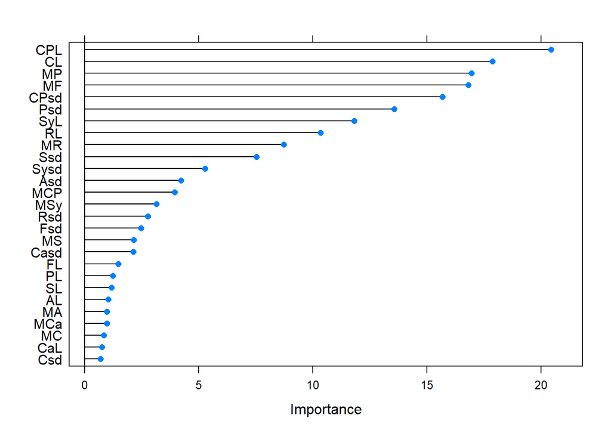

```r
rf_imp = varImp(rf.train, scale = F)
plot(rf_imp, scales = list(y = list(cex = .95)))
```

```r
rfPred = predict(rf.train, newdata = dataTest)
CM = confusionMatrix(factor(rfPred), dataTest$D)$table
confusionMatrix(factor(rfPred), dataTest$D)$overall[1]
```

```
##  Accuracy
## 0.9191919
```

```r
CM
```

```
##           Reference
## Prediction Benign Malign
##     Benign     59      1
##     Malign      7     32
```

```r
probability = predict(rf.train, dataTest, type = "prob")
roc.lda = roc(dataTest$D,probability[,2])
auc(roc.lda)
```

```
## Area under the curve: 0.9888
```

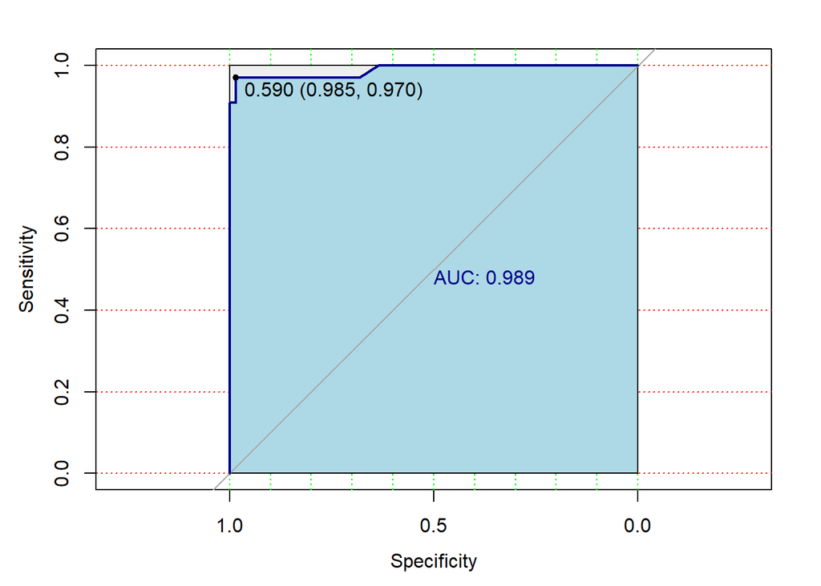

```r
plot.roc(dataTest$D, probability[,2],col="darkblue", print.auc = TRUE,  auc.polygon=TRUE, grid=c(0.1, 0.2),
         grid.col=c("green", "red"), max.auc.polygon=TRUE,
         auc.polygon.col="lightblue", print.thres=TRUE)
```

As we can see we have been trying to get a sensitivity of 100% because we believe its more important for what we are studying.

## **3.5 Gradient Boosting**

We will now use the gradient boosting package. We will define a grid and a ctrl:

```r
xgb_grid = expand.grid(
  nrounds = c(500,1000),
  eta = c(0.01, 0.001),
  max_depth = c(2, 4, 6),
  gamma = 1,
  colsample_bytree = c(0.2, 0.4),
  min_child_weight = c(1,5),
  subsample = 1
)
ctrl = trainControl(method = "repeatedcv",
                     number = 5, repeats = 1)
```

We will create the training function:

```r
xgb.train = train(D ~ .,  data = dataTrain,
                  trControl = ctrl,
                  metric="EconomicCost",
                  maximize = F,
                  tuneGrid = xgb_grid,
                  preProcess = c("center", "scale"),
                  method = "xgbTree"
)
```

Lets check the varaible importance:

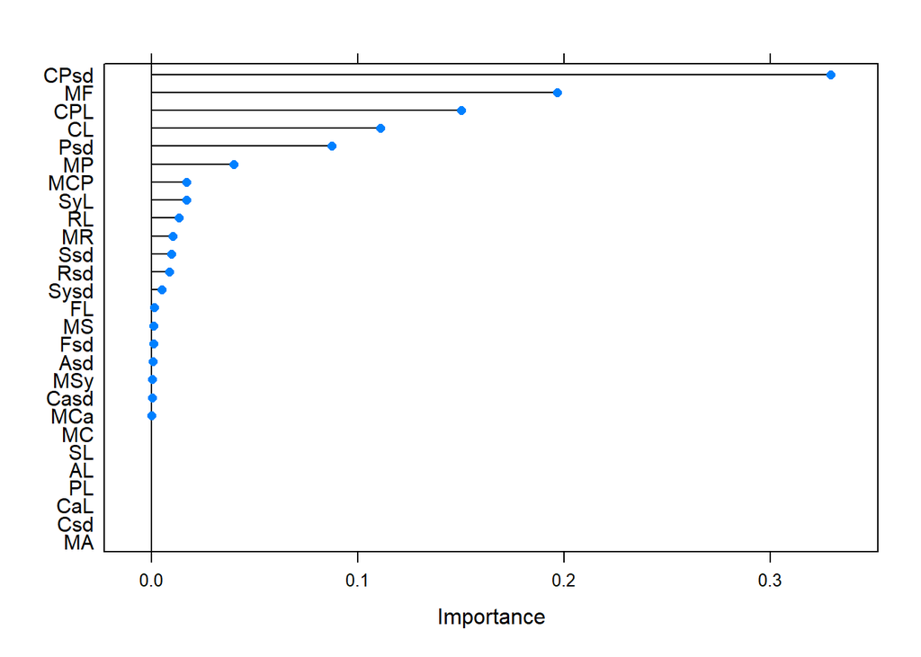

```r
xgb_imp = varImp(xgb.train, scale = F)
plot(xgb_imp, scales = list(y = list(cex = .95)))
```

```r
xgbPred = predict(xgb.train, newdata = dataTest)
CM = confusionMatrix(factor(xgbPred), dataTest$D)$table
confusionMatrix(factor(xgbPred), dataTest$D)$overall[1]
```

```
##  Accuracy
## 0.9292929
```

```r
CM
```

```
##           Reference
## Prediction Benign Malign
##     Benign     60      1
##     Malign      6     32
```

# **4.Advanced Regression**

As we are going to use lots of different prediction so we will be storing them in this data frame:

```r
meanFractalresults = data.frame(seq(1,99))
```

## **4.1 Linear Regression**

With the data classification we have seen what variables are more important for predicting if a tumor is either benign or malign. The most significant variable is the Mean Fractal Dimension of the cells of the tumor. This is why in this section we are going to try to predict it. First, we will see which variables have a greater correlation with the Mean Fractal Dimension:

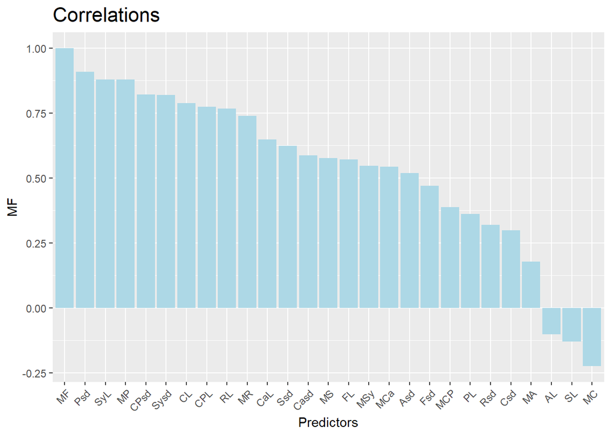

```r
corr_MF = sort(cor(dataTrain[,-c(1)])["MF",], decreasing = T)
corr = data.frame(corr_MF)
ggplot(corr,aes(x = row.names(corr), y = corr_MF)) +
  geom_bar(stat = "identity", fill = "lightblue") +
  scale_x_discrete(limits= row.names(corr)) +
  labs(x = "Predictors", y = "MF", title = "Correlations") +
  theme(plot.title = element_text(hjust = 0, size = rel(1.5)),
        axis.text.x = element_text(angle = 45, hjust = 1))
```

We can observe how there are 9 variables with a significantly high positive correlation. We will first try a simple linear regression with the variable with the most correlation, which is the Perimeters Standard Deviation:

```r
linFit = lm(MF ~ Psd, data=dataTrain)
summary(linFit)
```

```
##
## Call:
## lm(formula = MF ~ Psd, data = dataTrain)
##
## Residuals:
##       Min        1Q    Median        3Q       Max
## -0.092231 -0.015618 -0.001351  0.015136  0.100844
##
## Coefficients:
##             Estimate Std. Error t value Pr(>|t|)
## (Intercept) 0.035956   0.002071   17.36   <2e-16 ***
## Psd         1.636317   0.037888   43.19   <2e-16 ***
## ---
## Signif. codes:  0 '***' 0.001 '**' 0.01 '*' 0.05 '.' 0.1 ' ' 1
##
## Residual standard error: 0.02521 on 396 degrees of freedom
## Multiple R-squared:  0.8249, Adjusted R-squared:  0.8244
## F-statistic:  1865 on 1 and 396 DF,  p-value: < 2.2e-16
```

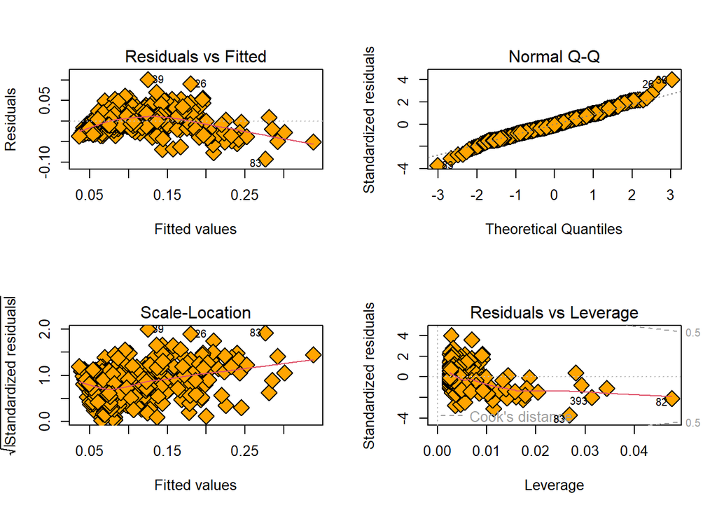

```r
par(mfrow = c(2, 2))
plot(linFit, pch = 23 ,bg ='orange',cex = 2)
```

```r
pr.simple = (predict(linFit, newdata=dataTest))
meanFractalresults = cbind(meanFractalresults, pr.simple)
cor(dataTest$MF, pr.simple)^2
```

```
## [1] 0.8727029
```

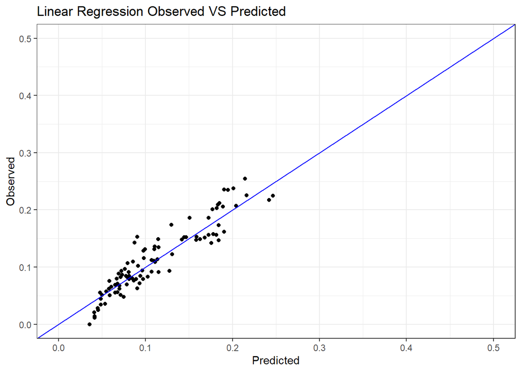

```r
qplot(meanFractalresults$pr.simple, dataTest$MF) +
  labs(title="Linear Regression Observed VS Predicted", x="Predicted", y="Observed") +
  lims(x = c(0, 0.5), y = c(0, 0.5)) +
  geom_abline(intercept = 0, slope = 1, colour = "blue") +
  theme_bw()
```

## **4.2 Multiple Regression**

For a first approach, we will develop a model using the variables we saw that ahd a greater correlation:

```r
linFitMultipleFirst = lm(MF ~ Psd + MP + SyL + Sysd + CPsd + CL + RL + CPL + MR , data = dataTrain)
summary(linFitMultipleFirst)
```

```
##
## Call:
## lm(formula = MF ~ Psd + MP + SyL + Sysd + CPsd + CL + RL + CPL +
##     MR, data = dataTrain)
##
## Residuals:
##       Min        1Q    Median        3Q       Max
## -0.054388 -0.008685  0.000121  0.007946  0.055372
##
## Coefficients:
##               Estimate Std. Error t value Pr(>|t|)
## (Intercept) -2.249e-03  1.135e-02  -0.198   0.8431
## Psd          1.886e+00  8.778e-02  21.486   <2e-16 ***
## MP          -7.166e-01  6.489e-02 -11.044   <2e-16 ***
## SyL          2.260e-01  1.660e-02  13.612   <2e-16 ***
## Sysd         3.988e-02  1.593e-02   2.504   0.0127 *
## CPsd         2.351e-04  3.338e-04   0.704   0.4816
## CL           1.572e-03  2.718e-03   0.579   0.5632
## RL          -2.080e-03  1.625e-03  -1.280   0.2013
## CPL         -1.511e-05  1.286e-05  -1.175   0.2409
## MR           1.195e-02  1.079e-02   1.108   0.2685
## ---
## Signif. codes:  0 '***' 0.001 '**' 0.01 '*' 0.05 '.' 0.1 ' ' 1
##
## Residual standard error: 0.01441 on 388 degrees of freedom
## Multiple R-squared:  0.9439, Adjusted R-squared:  0.9426
## F-statistic:   726 on 9 and 388 DF,  p-value: < 2.2e-16
```

We can see how introducing all this variables has risen a lot the R^2 value. Lets see the correlation of the the predicted data:

```r
pr.multipleFirst = (predict(linFitMultipleFirst, newdata=dataTest))
meanFractalresults = cbind(meanFractalresults, pr.multipleFirst)
cor(dataTest$MF, pr.multipleFirst)^2
```

```
## [1] 0.9286863
```

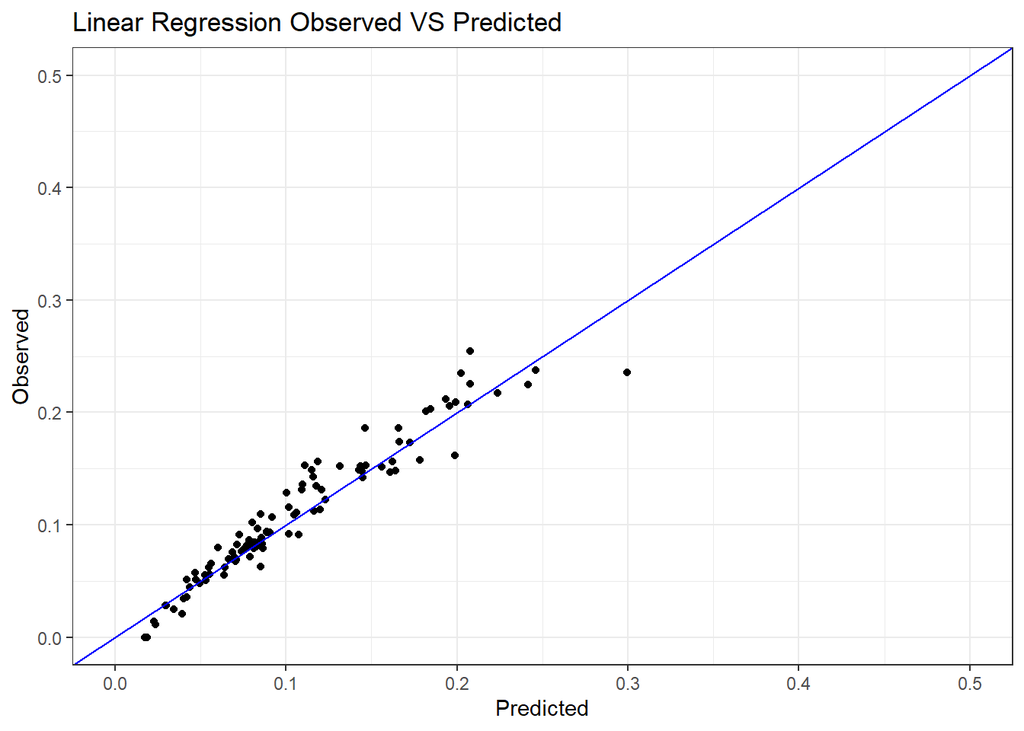

```r
qplot(meanFractalresults$pr.multipleFirst, dataTest$MF) +
  labs(title="Linear Regression Observed VS Predicted", x="Predicted", y="Observed") +
  lims(x = c(0,0.5), y = c(0,0.5)) +
  geom_abline(intercept = 0, slope = 1, colour = "blue") +
  theme_bw()
```

Comparing it with the previous graph we can see how point seem to adjust a bit better to the center. That is beacuse we have a better correlation.

## **4.3 Model Selection**

With this variables that have given a good model we will proceed to fin the best. Maybe our last model was over-trained and we could achieve the same correlation by including less variables.

** Disclaimer: the output of this cell has been hidden because it was too long and no relevant. It was just all the possible model combinations.

```r
model = MF ~ Psd + MP + SyL + Sysd + CPsd + CL + RL + CPL + MR

linFit = lm(model, data = dataTrain)

ols_step_all_possible(linFit)
```

```r
ols_step_best_subset(linFit)
```

```
##             Best Subsets Regression
## ------------------------------------------------
## Model Index    Predictors
## ------------------------------------------------
##      1         Psd
##      2         Psd SyL
##      3         Psd MP SyL
##      4         Psd MP SyL Sysd
##      5         Psd MP SyL Sysd CL
##      6         Psd MP SyL Sysd RL MR
##      7         Psd MP SyL Sysd CL RL CPL
##      8         Psd MP SyL Sysd CPsd RL CPL MR
##      9         Psd MP SyL Sysd CPsd CL RL CPL MR
## ------------------------------------------------
##
##                                                       Subsets Regression Summary
## --------------------------------------------------------------------------------------------------------------------------------------
##                        Adj.        Pred
## Model    R-Square    R-Square    R-Square      C(p)         AIC           SBIC          SBC         MSEP      FPE      HSP       APC
## --------------------------------------------------------------------------------------------------------------------------------------
##   1        0.8249      0.8244      0.8223    818.2687    -1796.3426    -2929.4067    -1784.3832    0.2529    6e-04    0.0000    0.1769
##   2        0.9009      0.9004      0.8986    294.0937    -2020.8980    -3153.2451    -2004.9522    0.1435    4e-04    0.0000    0.1006
##   3        0.9422      0.9417        0.94     10.2570    -2233.3830    -3362.9033    -2213.4508    0.0839    2e-04    0.0000    0.0590
##   4        0.9431      0.9426      0.9405      5.5846    -2238.0738    -3367.4369    -2214.1551    0.0827    2e-04    0.0000    0.0583
##   5        0.9433      0.9426      0.9403      6.2150    -2237.4612    -3366.7597    -2209.5560    0.0826    2e-04    0.0000    0.0584
##   6        0.9435      0.9427        0.94      6.8708    -2236.8275    -3366.0479    -2204.9359    0.0826    2e-04    0.0000    0.0585
##   7        0.9438      0.9428      0.9399      7.2863    -2236.4443    -3365.5622    -2200.5662    0.0825    2e-04    0.0000    0.0585
##   8        0.9439      0.9427      0.9393      8.3347    -2235.4183    -3364.4466    -2195.5538    0.0825    2e-04    0.0000    0.0587
##   9        0.9439      0.9426      0.9389     10.0000    -2233.7615    -3362.7224    -2189.9105    0.0826    2e-04    0.0000    0.0589
## --------------------------------------------------------------------------------------------------------------------------------------
## AIC: Akaike Information Criteria
##  SBIC: Sawa's Bayesian Information Criteria
##  SBC: Schwarz Bayesian Criteria
##  MSEP: Estimated error of prediction, assuming multivariate normality
##  FPE: Final Prediction Error
##  HSP: Hocking's Sp
##  APC: Amemiya Prediction Criteria
```

As we can observe from the model 3 we get pretty much the same value of R^2. While it is true that the best model would still be the last one (the one used in the previous section) the difference is bearly noticeable and we would be overtraining the model. Therefore we will stick with model 3 for the moment, which takes as variables:

- The Perimeter Standard Deviation
- Symmetry Largest Value
- Mean Perimeter.

As we can observe again, this three variables are goemtric related.

```r
ols_step_forward_p(linFit)
```

```
##
##                              Selection Summary
## ----------------------------------------------------------------------------
##         Variable                  Adj.
## Step    Entered     R-Square    R-Square      C(p)         AIC         RMSE
## ----------------------------------------------------------------------------
##    1    Psd           0.8249      0.8244    818.2687    -1796.3426    0.0252
##    2    SyL           0.9009      0.9004    294.0937    -2020.8980    0.0190
##    3    MP            0.9422      0.9417     10.2570    -2233.3830    0.0145
##    4    Sysd          0.9431      0.9426      5.5846    -2238.0738    0.0144
##    5    CL            0.9433      0.9426      6.2150    -2237.4612    0.0144
##    6    RL            0.9435      0.9427      6.9729    -2236.7236    0.0144
##    7    CPL           0.9438      0.9428      7.2863    -2236.4443    0.0144
## ----------------------------------------------------------------------------
```

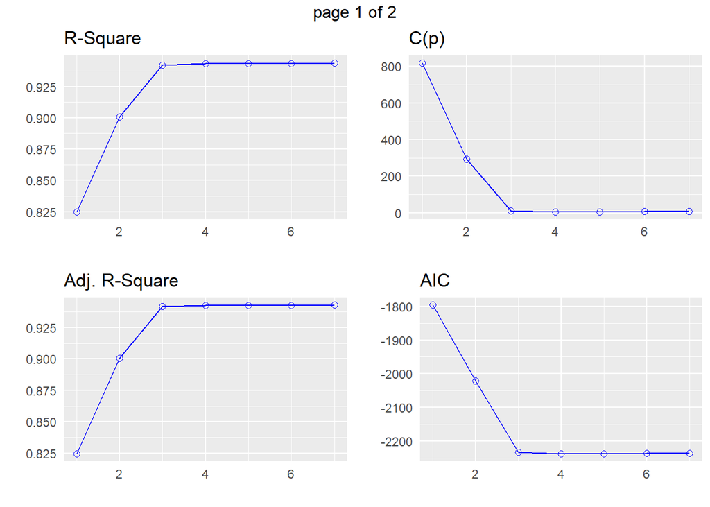

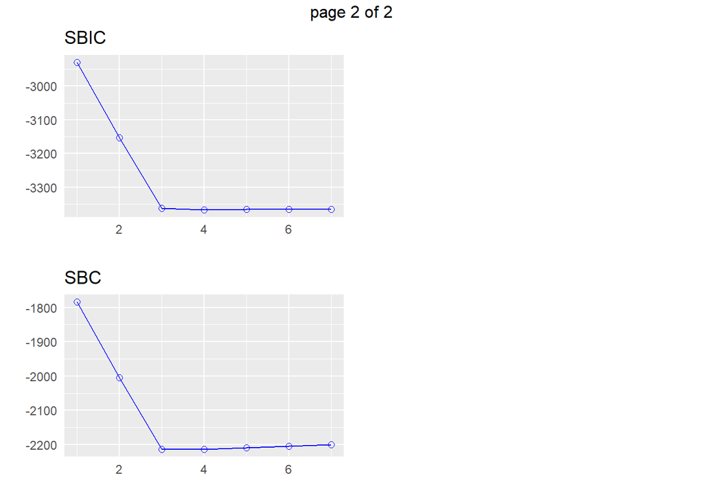

```r
plot(ols_step_forward_p(linFit))
```

With this graphs it is easier to see how the R Square value becomes stable so we do not need to include more variables. We would be over-training the model. For one last comparison we can check this table were this is even more clear:

```r
ols_step_backward_aic(linFit)
```

```
##
##
##                     Backward Elimination Summary
## ------------------------------------------------------------------
## Variable         AIC        RSS     Sum Sq     R-Sq      Adj. R-Sq
## ------------------------------------------------------------------
## Full Model    -2233.761    0.081     1.356    0.94395      0.94265
## CL            -2235.418    0.081     1.356    0.94390      0.94275
## CPL           -2236.323    0.081     1.356    0.94375      0.94274
## CPsd          -2236.828    0.081     1.356    0.94353      0.94267
## ------------------------------------------------------------------
```

Lets take an insight on our chosen model:

```r
linFitMultModel = lm(MF ~ Psd + MP + SyL, data = dataTrain)
summary(linFitMultModel)
```

```
##
## Call:
## lm(formula = MF ~ Psd + MP + SyL, data = dataTrain)
##
## Residuals:
##       Min        1Q    Median        3Q       Max
## -0.051720 -0.009315  0.000155  0.008753  0.053822
##
## Coefficients:
##              Estimate Std. Error t value Pr(>|t|)
## (Intercept)  0.016603   0.001408   11.79   <2e-16 ***
## Psd          1.969549   0.066273   29.72   <2e-16 ***
## MP          -0.830414   0.049506  -16.77   <2e-16 ***
## SyL          0.271420   0.009958   27.26   <2e-16 ***
## ---
## Signif. codes:  0 '***' 0.001 '**' 0.01 '*' 0.05 '.' 0.1 ' ' 1
##
## Residual standard error: 0.01452 on 394 degrees of freedom
## Multiple R-squared:  0.9422, Adjusted R-squared:  0.9417
## F-statistic:  2140 on 3 and 394 DF,  p-value: < 2.2e-16
```

We can still see how the highest coefficient is for the Perimeter Standard Deviation. This means that it is still the most relevant as it will have the most importance as it will contribute the most to the Mean Fractal Dimension. It is also interesting to notice how the coefficient for the Mean Perimeter is negative. This means that the bigger the perimeter, the smallest the fractal dimension. Lets quickly recall one of the graphs we saw in the Data Visualization section:

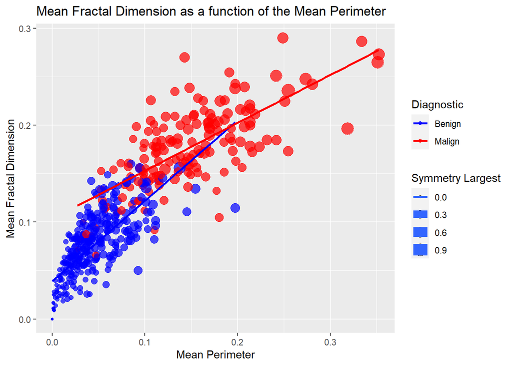

```r
ggplot(dataClean, aes(x=MP, y=MF, size = SyL, color = D)) +
  geom_point(alpha=0.7) + geom_smooth(method=lm, se=FALSE, formula = y~x) +
  xlab("Mean Perimeter") + ylab("Mean Fractal Dimension") + labs(color = "Diagnostic", size = "Symmetry Largest") +
  ggtitle("Mean Fractal Dimension as a function of the Mean Perimeter") + scale_color_manual(values=c('#0000FF','#FF0000'))
```

As we can see malign tumors have a bigger Perimeter and Fractal Dimension. This contradicts what we are seeing. This is because the model is using it as a corrector as both of the two other coefficients are positive.

Lets use our model to predict the data:

```r
pr.multipleModel = predict(linFitMultModel, newdata = dataTest)
meanFractalresults = cbind(meanFractalresults, pr.multipleModel)
cor(dataTest$MF, pr.multipleModel)^2
```

```
## [1] 0.9221395
```

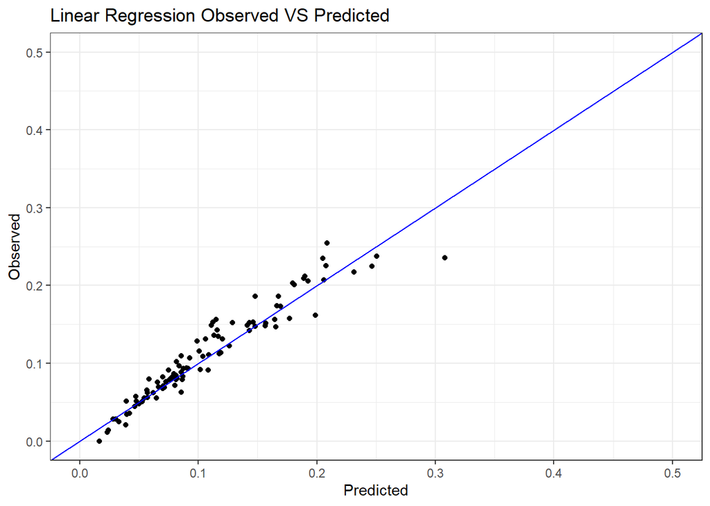

```r
qplot(meanFractalresults$pr.multipleModel, dataTest$MF) +
  labs(title="Linear Regression Observed VS Predicted", x="Predicted", y="Observed") +
  lims(x = c(0,0.5), y = c(0,0.5)) +
  geom_abline(intercept = 0, slope = 1, colour = "blue") +
  theme_bw()
```

We can not see much difference with the previous graph because, as we commented, the models have pretty much the same results.

## **4.4 Advanced Regression Models**

### **4.4.1 Ridge Regression**

We will first define the matrix for the model:

```r
X = model.matrix(MF ~ Psd + MP + SyL, data = dataTrain)

Y = dataTrain$MF
```

Secondly, we create a grid with the possible values for lambda:

```r
grid = seq(0, .1, length = 100)
```

Now, we create and plot the model:

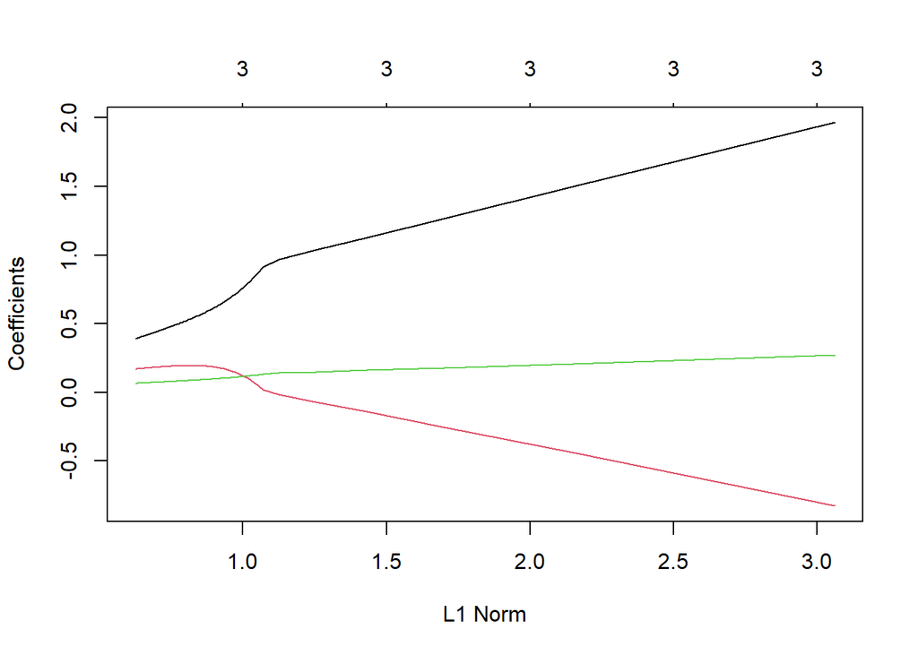

```r
ridge.mod = glmnet(X, Y, alpha = 0, lambda = grid)
plot(ridge.mod)
```

This graph its difficult to understand. Lets plot another one to see the best value of lambda:

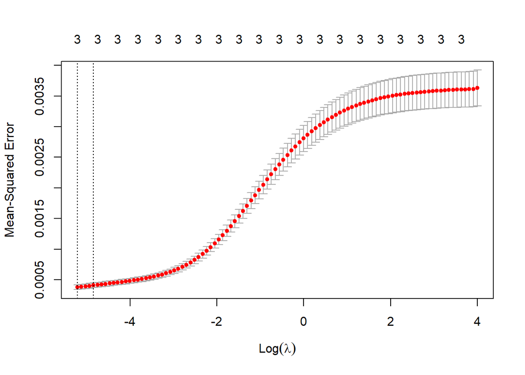

```r
ridge.cv = cv.glmnet(X, Y, type.measure="mse", alpha=0)
plot(ridge.cv)
```

As we can see the best value for lambda is the lowest one. Lets obtain the exact value:

```r
opt.lambda = ridge.cv$lambda.min
opt.lambda
```

```
## [1] 0.005456737
```

```r
lambda.index = which(ridge.cv$lambda == ridge.cv$lambda.1se)
beta.ridge = ridge.cv$glmnet.fit$beta[, lambda.index]
beta.ridge
```

```
## (Intercept)         Psd          MP         SyL
##  0.00000000  0.84469075  0.06983231  0.12603134
```

As we can see now, all the coefficients are positive. This makes more sense with the graphs previously analyzed (as a grater perimeter suggested a greater fractal dimension). Now the modulus of the coefficients is lower which makes sense again as now we do not have any negative one.

```r
X.test = model.matrix(MF ~ Psd + MP + SyL, data = dataTest)

ridge.pred = predict(ridge.cv$glmnet.fit, s = opt.lambda, newx = X.test)
meanFractalresults = cbind(meanFractalresults, ridge.pred)
```

Lets check the R-squared value of this model:

```r
y.test = dataTest$MF

postResample(pred = ridge.pred,  obs = y.test)
```

```
##       RMSE   Rsquared        MAE
## 0.02131982 0.88591555 0.01622555
```

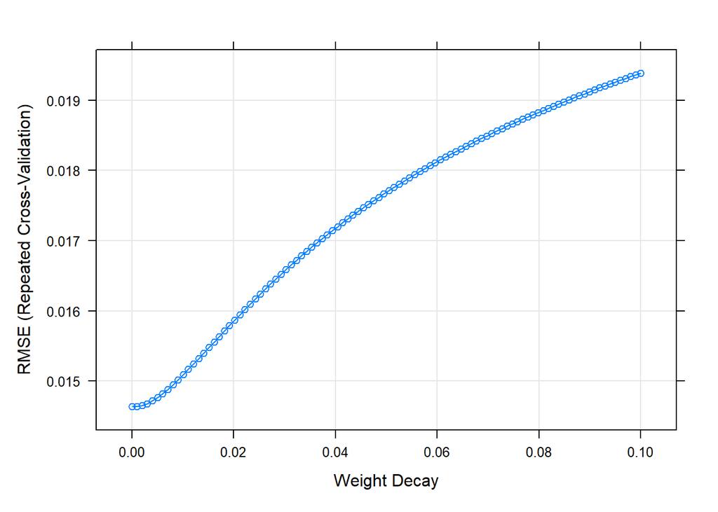

```r
ridge_grid = expand.grid(lambda = seq(0, 0.1, length = 100))
ctrl = trainControl(method = "repeatedcv",
                     number = 5, repeats = 1)

ridge_tune = train(MF ~ Psd + MP + SyL, data = dataTrain,
                    method = 'ridge',
                    preProc = c('scale','center'),
                    tuneGrid = ridge_grid,
                    trControl = ctrl)
plot(ridge_tune)
```

We can observe how a greater Weight Decay means a greater RMSE. We can find the best tune (lambda):

```r
ridge_tune$bestTune
```

```
##        lambda
## 2 0.001010101
```

```r
meanFractalresults$ridge.caret <- predict(ridge_tune, dataTest)

postResample(pred = meanFractalresults$ridge.caret,  obs = dataTest$MF)
```

```
##       RMSE   Rsquared        MAE
## 0.01742232 0.92205053 0.01259983
```

### **4.4.2 The Lasso**

Again using caret, we can use the method lasso to predict our new model:

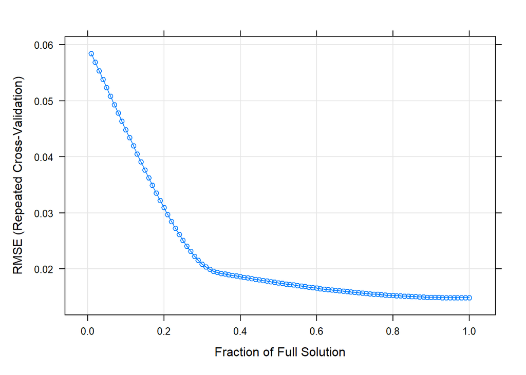

```r
lasso_grid = expand.grid(fraction = seq(.01, 1, length = 100))

lasso_tune = train(MF ~ Psd + MP + SyL, data = dataTrain,
                    method = 'lasso',
                    preProc = c('scale','center'),
                    tuneGrid = lasso_grid,
                    trControl = ctrl)
plot(lasso_tune)
```

Again from this graph lets obtain the best value:

```r
lasso_tune$bestTune
```

```
##    fraction
## 99     0.99
```

Applying this tune lets observe our results:

```r
meanFractalresults$lasso = predict(lasso_tune, dataTest)
postResample(pred = meanFractalresults$lasso,  obs = dataTest$MF)
```

```
##       RMSE   Rsquared        MAE
## 0.01741618 0.92213912 0.01258570
```

### **4.4.3 Elastic Net**

As a last approach in Advanced Regression lets check using the method glmnet and an elastic grid:

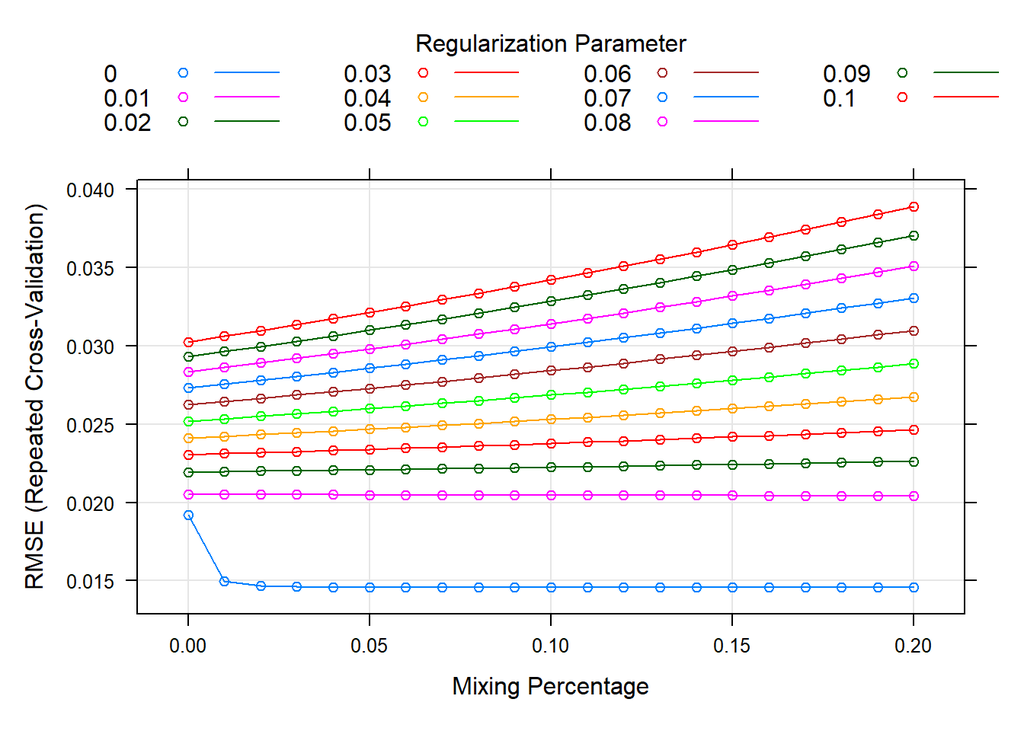

```r
elastic_grid = expand.grid(alpha = seq(0, .2, 0.01), lambda = seq(0, .1, 0.01))

glmnet_tune = train(MF ~ Psd + MP + SyL, data = dataTrain,
                     method = 'glmnet',
                     preProc = c('scale','center'),
                     tuneGrid = elastic_grid,
                     trControl = ctrl)

plot(glmnet_tune)
```

Lets obtain the best tune from the graph:

```r
glmnet_tune$bestTune
```

```
##     alpha lambda
## 133  0.12      0
```

And with this tune, lets predict and store the values:

```r
meanFractalresults$glmnet = predict(glmnet_tune, dataTest)
postResample(pred = meanFractalresults$glmnet,  obs = dataTest$MF)
```

```
##       RMSE   Rsquared        MAE
## 0.01742443 0.92203724 0.01260114
```

Again, the same R-squared value. We assume this is the maximum we can obtain no matter what method we use.

## **4.5 Machine Learning Tools**

### **4.5.1 kNN**

We will start by applying the k nearest neighbour method. In this method we have three parameters that we must select:

- kernel: how do we want the method to be executed.
- distance: the chosen parameters for the Minkowski distance.
- kmax: how many neighbours do we want to consider.

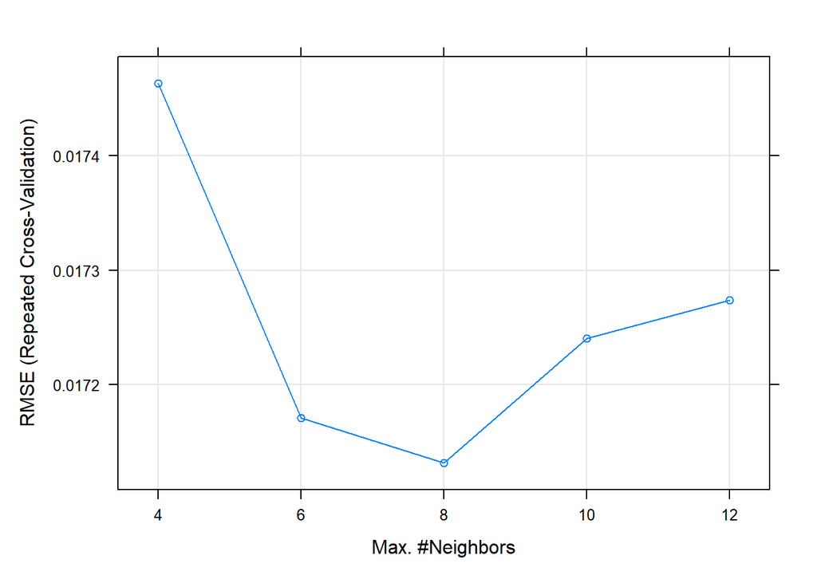

```r
knn_tune = train(MF ~ Psd + MP + SyL,
                  data = dataTrain,
                  method = "kknn",
                  preProc = c('scale','center'),
                  tuneGrid = data.frame(kmax = c(4, 6, 8, 10 ,12),distance = 2,kernel = 'optimal'),
                  trControl = ctrl)
plot(knn_tune)
```

```r
meanFractalresults$knn = predict(knn_tune, dataTest)

postResample(pred = meanFractalresults$knn,  obs = dataTest$MF)
```

```
##       RMSE   Rsquared        MAE
## 0.01831771 0.91172923 0.01335361
```

We obtain a 0.91 R-squared value. It is a great value but not the highest until now.

### **4.5.2 Random Forests**

We apply a new classification method using Random Forest. We will use a 100 trees:

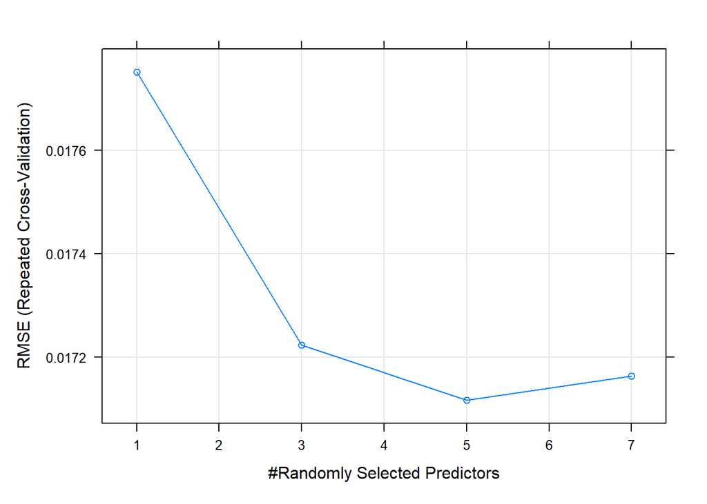

```r
rf_tune <- train(MF ~ Psd + MP + SyL,
                 data = dataTrain,
                 method = "rf",
                 preProc = c('scale','center'),
                 trControl = ctrl,
                 ntree = 100,
                 tuneGrid = data.frame(mtry=c(1,3,5,7)),
                 importance = TRUE)

plot(rf_tune)
```

With 5 predictors we get the less RSME. Lets predict and check the R-squared value:

```r
meanFractalresults$rf = predict(rf_tune, dataTest)

postResample(pred = meanFractalresults$rf,  obs = dataTest$MF)
```

```
##       RMSE   Rsquared        MAE
## 0.01813038 0.91309479 0.01309852
```

Again we get a very similar R-squared (a bit under). The model is also very good. We can see if the Random Forest agrees with the variable importance we have seen in previous sections:

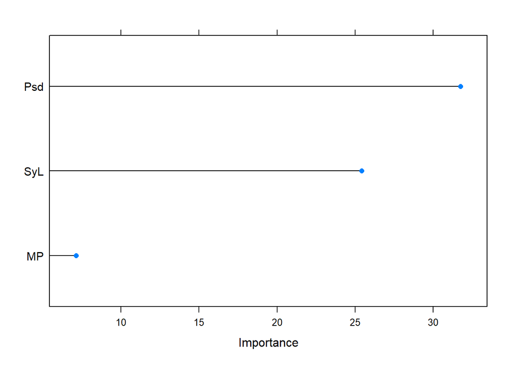

```r
plot(varImp(rf_tune, scale = F), scales = list(y = list(cex = .95)))
```

This agrees with what we have seen:

- The most important variable is the Perimeter Standard Deviation
- Second, the largest Symmetry value
- On third place, the mean perimeter

## **4.6 Conclusions**

### **4.6.1 Final Predictions**

```r
apply(meanFractalresults[-1], 2, function(x) mean(abs(x - dataTest$MF)))
```

```
##        pr.simple pr.multipleFirst pr.multipleModel               s1
##       0.01811001       0.01199597       0.01257587       0.01622555
##      ridge.caret            lasso           glmnet              knn
##       0.01259983       0.01258570       0.01260114       0.01335361
##               rf
##       0.01309852
```

```r
meanFractalresults$comb = (meanFractalresults$knn + meanFractalresults$rf + meanFractalresults$glmnet)/3

postResample(pred = meanFractalresults$comb,  obs = dataTest$MF)
```

```
##       RMSE   Rsquared        MAE
## 0.01636238 0.93056497 0.01183230
```

As a limitation, it is true that all the variables we are using to predict the Mean Fractal Dimension are geometry related. This means that they are maybe directly related to it and that might be why the predictions are so good. Notwithstanding the foregoing, we have seen in the classification section that Fractal Dimension has a higher importance than the other geometry related variables. Also, the other geometric related variables are easier to calculate.

This means that with such a great accuracy when predicting if we did not have the means to calculate the Fractal Dimension we could obtain from the other variables and then use it to predict wether a tumor is benign or malign.

### **4.6.2 Prediction Intervals**

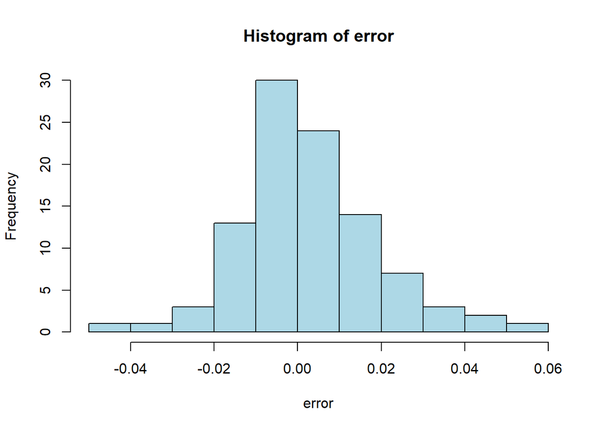

```r
yhat = meanFractalresults$comb
y = dataTest$MF
error = dataTest$MF - yhat
hist(error, col = "lightblue")
```

```r
noise = error[1:20]
lwr = yhat[21:length(yhat)] + quantile(noise,0.05, na.rm=T)
upr = yhat[21:length(yhat)] + quantile(noise,0.95, na.rm=T)
```

We now create the predictions and count how many are out of the interval:

```r
predictions = data.frame(real=y[21:length(y)], fit=yhat[21:length(yhat)], lwr=lwr, upr=upr)

predictions = predictions %>% mutate(out=factor(if_else(real<lwr | real>upr,1,0)))


mean(predictions$out==1)
```

```
## [1] 0.1392405
```

13% of the observations are outside. We can visualize it here:

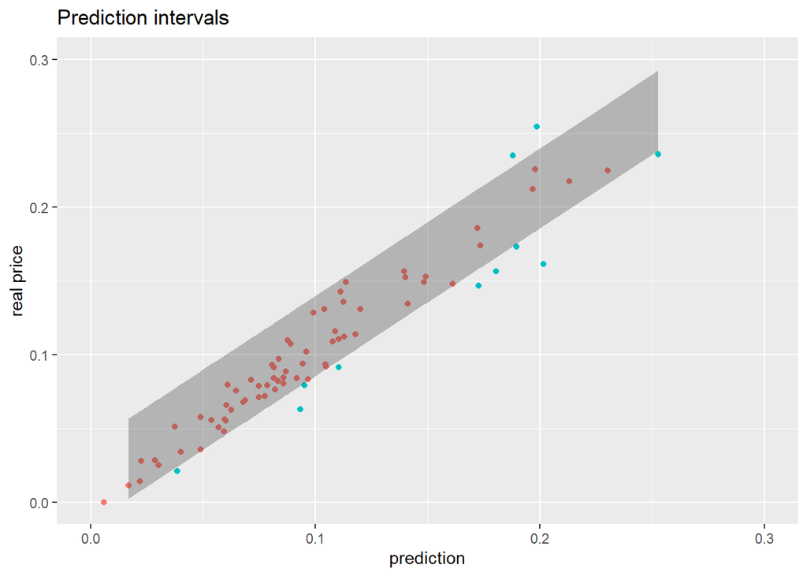

```r
ggplot(predictions, aes(x=fit, y=real))+
  geom_point(aes(color=out)) + theme(legend.position="none") +
  xlim(0, 0.3) + ylim(0, 0.3)+
  geom_ribbon(data=predictions,aes(ymin=lwr,ymax=upr),alpha=0.3) +
  labs(title = "Prediction intervals", x = "prediction",y="real price")
```

### **4.6.3 Conclusions about the models**

# **5. Insight on Fractal Dimension**

As a conclusion to the assignment it would be good to understand what is the Fractal Dimension as it has come out to be the most important variable to predict if a tumor is benign or malign.

The Fractal dimension is a ratio which provides a statistical index which allows to compare how complex the pattern (border) of something is. Applied to our case, the Fractal Dimension represents how complex is the border of the cells analyzed. It has been seen how the more complex this border is the more probable for the tumor to be malign.

“Fractal analysis of images of breast tissue specimens provides a numeric description of tumor growth patterns as a continuous number between 1 and 2. This number, the fractal dimension, is an objective and reproducible measure of the complexity of the tissue architecture of the biopsy specimen.” (University of Calgary, 2011)

It is actually a very important and used variable when determining if a cancer is malign or benign, and this assignment has proven so.